# Statistical model for Wood ants: genetic differentiation and trail networks

Daniel Franks

# Project structure

| File | Contents |
| --- | --- |
| Statistical_methods.md | Concise paper methods, model formulations and prior justifications |
| process_data.R | Workbook processing, FST estimates, exclusions and data validation |
| analysis_helpers/genetic_screening.R | Shared ant, locus and nest screening for all analyses |
| AMOVA/AMOVA.R | AMOVA adapted analysis to the shared genotypes |
| analysis_helpers/model_helpers.R | Shared predictor transformations and sampling refinement |
| analysis_helpers/prior_checks.R | Reusable prior simulations and integration |
| analysis_helpers/diagnostics.R | Sampling and posterior predictive checks |
| tests/model_implementation.R | Endpoint-indexing checks for changes to model code |
| analysis_helpers/predictions.R | Reusable prediction calculations and marginal effects |
| analysis_helpers/presentation.R | Figure export, table display and notebook formatting |
| analysis_helpers/notebook_outputs.lua | Preserves notebook outputs when saving and sharing; keep this file in place |

```r
install.packages(c(
  "rmarkdown", "readxl", "tidyverse", "adegenet", "hierfstat",
  "geosphere", "poppr", "brms", "posterior", "bayesplot", "gridExtra", "ragg", "svglite", "base64enc"
))
install.packages("cmdstanr", repos = c("https://stan-dev.r-universe.dev", getOption("repos")))
cmdstanr::install_cmdstan(version = "2.39.0")
```

# This notebook

The methods document gives the concise paper methods, but there are important points made in this notebook, and the results can be found here too.

| Analysis | Question | Paper figures and results |
| --- | --- | --- |
| AMOVA | How is genetic variation partitioned among colonies, nests and ants? | Results |
| Model 1: Genetic differentiation | How does differentiation vary with distance within and between colonies? | Results and figures |
| Model 2: Trail presence | Which nest pairs are more likely to have a trail? | Results and figures |
| Model 3: Trail investment | How does investment vary among existing trails? | Results and figures |

# Pre-processing changes

## Trail investment and pair-specific normalisation

The original calculation was:

```r
trail_investment = (strength * distance_fine_scale) /
  mean(c(from_nest_size, from_nest_size), na.rm = T)
```

This uses ‘from_nest_size’ twice, where it should be c(from_nest_size, to_nest_size).

Additionally, I changed the normalisation from a common denominator to the mean population of each pair of connected nests. I believe this is what we really want. Let me know if it’s not. This pair-specific mean expresses trail allocation relative to the workforce of the connected nests, rather than simply rescaling all trails by one constant.

It is an index of relative workforce allocation, assuming these nest populations represent the workforce supporting the trail. Length in centimetres and strength in ants/cm give a dimensionless investment index.

The revised calculation in process_data.R is:

```r
mean_endpoint_size = dplyr::if_else(
  from_valid_size & to_valid_size,
  (from_nest_size + to_nest_size) / 2,
  NA_real_
)

trail_investment = dplyr::if_else(
  listed_trail & is.finite(strength) &
    is.finite(trail_length_cm) & !is.na(mean_endpoint_size),
  strength * trail_length_cm / mean_endpoint_size,
  NA_real_
)
```

## Genotypes: combine the two allele columns into one diploid locus

The original conversion passed the allele columns directly to `df2genind()`:

```r
microsat_genind <- df2genind(
  microsat_data |>
    select(-c(ant_ID, microsat_sample_ID, label)),
  ploidy = 2,
  ind.names = microsat_data$microsat_sample_ID,
  pop = microsat_data$label,
  sep = ","
)
```

The excel file has 22 allele columns for 11 loci. `df2genind()` expects one column per locus containing both calls: `ploidy = 2` does not pair columns, and `sep` separates alleles within a cell. The original conversion therefore treated each allele column as a separate locus.

The correction combines each marker’s two calls. process_data.R also preserves identifiers and checks allele-order invariance.

```r
# Combine the two allele calls for each locus.
diploid_calls <- lapply(loci, function(locus) {
  a <- microsat_raw[[paste0(locus, "_1")]]
  b <- microsat_raw[[paste0(locus, "_2")]]
  a[a == "000"] <- NA_character_
  b[b == "000"] <- NA_character_
  dplyr::if_else(
    is.na(a) | is.na(b), NA_character_,
    paste0("A", a, "/A", b)
  )
})
diploid_calls <- as.data.frame(setNames(diploid_calls, loci))
keep_ant <- rowSums(!is.na(diploid_calls)) > 0

# One column per diploid locus; two alleles within each cell.
genotype <- adegenet::df2genind(
  diploid_calls[keep_ant, , drop = FALSE],
  ploidy = 2, type = "codom", sep = "/",
  ind.names = microsat_raw$microsat_sample_ID[keep_ant],
  pop = factor(microsat_raw$label[keep_ant]),
  NA.char = NA_character_
)
```

For example, allele calls `150` and `154` become `A150/A154` in one locus column. `000` is assumed to represent a failed call.

Missing allele calls made 1,122 of 15,928 genotypes unusable; one ant with no usable genotypes was excluded. Checks confirm 11 loci.

# Data processing

This call processes the workbook, applies the shared genetic screen and recalculates FST. All analyses below use the screened data.

```r
processed_data <- process_wood_ant_data("data/wood_ant_data.xlsx")
genetic_screening <- screen_genotypes(processed_data$genotypes)
screened_data <- rebuild_screened_data(processed_data, genetic_screening)
analysis_data <- screened_data$analysis_data
```

## Sample sizes and exclusions

**Genotype processing.** Fifteen of 196 nests had no genotype samples. The remaining 181 nests contributed 1,448 ants, with 11 microsatellite loci per ant. We treated an ant’s genotype at a locus as missing if either allele call had failed; this affected 1,122 of 15,928 genotypes (7.0%). Missing genotypes were not imputed; ants contributed data at loci where they had usable genotypes. One ant with no usable genotypes was excluded, leaving 1,447 ants from 181 nests before screening.

## Shared genetic screening

All analyses use the same screened genotypes. Restricting to known colonies retained 847 ants from 106 nests, excluding 600 ants from 75 nests of unknown colony identity. We then removed 55 ants missing more than 30% of the 11 loci, followed by FE16 and FE21, which exceeded 5% missingness among the remaining ants. One nest (colony 4, N19) contained only three remaining ants and was excluded because it fell below the four-ant minimum. Excluding this nest also removed one of the 86 mapped internest trails, leaving 85. This left 789 ants from 105 nests in ten colonies, with nine loci. The thresholds were applied once, in that order.

```r
show_table(genetic_screening$counts |> transmute(Stage = stage, Ants = ants, Nests = nests, Loci = loci),
  caption = "Sequential genetic screening")
show_table(genetic_screening$locus_missingness |> filter(!retained) |>
  transmute(Locus = locus, `Missing genotypes (%)` = 100 * missing_fraction), digits = 2,
  caption = "Loci excluded after the ant screen")
```

Sequential genetic screening

| Stage | Ants | Nests | Loci |
| --- | --- | --- | --- |
| Typed workbook genotypes | 1447 | 181 | 11 |
| Known colonies | 847 | 106 | 11 |
| Ant missingness at most 30% | 792 | 106 | 11 |
| Locus missingness at most 5% | 792 | 106 | 9 |
| At least four ants per nest | 789 | 105 | 9 |

Loci excluded after the ant screen

| Locus | Missing genotypes (%) |
| --- | --- |
| FE16 | 9.85 |
| FE21 | 6.19 |

FST is calculated from these screened genotypes. Partially failed loci remain missing, and the two fully typed ants absent from the supplied Genepop file are retained.

**Statistical models.** Pair-level exclusions were applied after FST estimation. The genetic model retained all 5,460 pairs (662 within and 4,798 between colonies), with no exclusions for missing FST or distance. Trail presence used the 662 within-colony pairs, excluding 17 because one nest lacked the population estimate needed for food difference, leaving 645. Investment excluded 577 within-colony pairs without trails, then one of 85 observed trails because that same missing estimate prevented calculation of food difference and investment, leaving 84. These exclusions overlap and should not be summed.

```r
audit <- processed_data
audit[names(screened_data)] <- screened_data
show_data_audit(audit)
```

Workbook exclusions before genetic screening, by type of record

| Records | Available | Excluded | Retained | Reason |
| --- | --- | --- | --- | --- |
| Diploid ant–locus calls | 15928 | 1122 | 14806 | At least one failed or missing allele |
| Ants | 1448 | 1 | 1447 | No typed locus |
| Nests | 196 | 15 | 181 | No usable genotype sample |
| Internest trails | 87 | 1 | 86 | Nest identifier could not be matched |
| Foraging trails | 97 | 2 | 95 | Source nest identifier could not be matched |

Model samples after applying each analysis’s scope

| Analysis | Eligible pairs | Excluded | Analysed pairs | Nests | Reason |
| --- | --- | --- | --- | --- | --- |
| Genetic differentiation | 5460 | 0 | 5460 | 105 | None |
| Trail presence | 662 | 17 | 645 | 104 | Missing nest size |
| Trail investment | 85 | 1 | 84 | 94 | Missing nest size |

These omissions are simplest to justify if missingness is unrelated to observed or unobserved characteristics (missing completely at random), which was not established. Selective genotype failure could bias FST; selective missingness in model predictors could bias the regression estimates. Screening does not propagate FST estimation uncertainty.

## FST estimates

```r
show_fst_audit(screened_data)
```

FST estimates: support and missing values

| Estimator | Minimum | Maximum | Negative | Zero | At least one | Missing |
| --- | --- | --- | --- | --- | --- | --- |
| FST_Latter | 0.0258 | 0.3446 | 0 | 0 | 0 | 0 |
| FST_WC84 | -0.0491 | 0.3062 | 295 | 0 | 0 | 0 |
| FST_Nei | -0.0496 | 0.3060 | 300 | 1 | 0 | 0 |

Agreement of alternative FST estimates with Latter

| Estimator | Pairs | Correlation with Latter | Mean difference from Latter |
| --- | --- | --- | --- |
| Weir–Cockerham | All | 0.9840 | -0.0621 |
| Weir–Cockerham | Within colony | 0.9807 | -0.0637 |
| Weir–Cockerham | Between colonies | 0.9834 | -0.0618 |
| Nei | All | 0.9870 | -0.0613 |
| Nei | Within colony | 0.9833 | -0.0632 |
| Nei | Between colonies | 0.9866 | -0.0611 |

# AMOVA: Partitioning genetic variation

The AMOVA partitions differences among diploid ants into variation between colonies, between nests within colonies and between ants within nests. Uses the shared screened genotypes, allele-frequency distances with a quasi-Euclidean correction, and 999 permutations. Missing genotypes are not imputed; distances use the available allele entries for each pair, rescaled for the number available.

```r
amova <- run_wood_ant_amova(genetic_screening$genotypes, seed = 20261021L, permutations = 999L)
show_table(amova$summary |> rename(`Sum of squares` = sum_squares, `Mean square` = mean_squares),
  digits = 3, caption = "AMOVA sums of squares and degrees of freedom")
show_table(left_join(amova$variance, select(amova$permutation, Source, p_value), by = "Source") |>
  rename(Variance = variance, `Variance (%)` = percent, `Permutation p` = p_value),
  digits = 4, caption = "AMOVA variance components and permutation tests")
show_table(amova$phi, digits = 4, caption = "Hierarchical genetic differentiation (Phi statistics)")
```

AMOVA sums of squares and degrees of freedom

| Source | df | Sum of squares | Mean square |
| --- | --- | --- | --- |
| Between colonies | 9 | 188.547 | 20.950 |
| Between nests within colonies | 95 | 396.636 | 4.175 |
| Between ants within nests | 684 | 1719.888 | 2.514 |
| Total | 788 | 2305.070 | 2.925 |

AMOVA variance components and permutation tests

| Source | Variance | Variance (%) | Permutation p |
| --- | --- | --- | --- |
| Between colonies | 0.2194 | 7.4242 | 0.001 |
| Between nests within colonies | 0.2212 | 7.4870 | 0.001 |
| Between ants within nests | 2.5145 | 85.0888 | 0.001 |
| Total | 2.9551 | 100.0000 | NA |

Hierarchical genetic differentiation (Phi statistics)

| Comparison | Phi |
| --- | --- |
| Nests relative to the total | 0.1491 |
| Nests within colonies | 0.0809 |
| Colonies relative to the total | 0.0742 |

**Interpretation.** Most variation was between ants within nests (85.1%), with 7.5% between nests within colonies and 7.4% between colonies. Each variance-component test gave a permutation p-value of 0.001 (from 999 permutations).

# Analysis conventions

All models are fitted separately and estimate adjusted associations. We discuss causal limitations but have not conducted a formal causal or confounding sensitivity analysis.

Partial pooling allows nests, colonies and colony pairs to differ, while drawing less precisely estimated effects towards their population means.

In the notation, $\operatorname{Normal}(\mu,s)$ is parameterised by mean and standard deviation. $\operatorname{HalfNormal}(0,s)$ is a $\operatorname{Normal}(0,s)$ distribution restricted to positive values, and $\operatorname{Exponential}(\lambda)$ uses rate $\lambda$. $\operatorname{MVNormal}(\mathbf m,\Sigma)$ uses a covariance matrix as its second argument. Priors on population-level coefficients and scale parameters are independent unless stated otherwise.

Within each analysis, $i=1,\ldots,n$ indexes its retained pairs. Pair $i=(a_i,b_i)$ joins two distinct nests; exchanging the endpoints does not change the model. Nest $j$ belongs to colony $c(j)$ when its colony is known.

I specified regularising priors, ran prior-predictive checks, fitted models, and ran posterior predictions. Priors used biological expectations, common sense (e.g. pooling and shrinkage) and measurement units, without matching observed outcomes. Except for the trail-presence distance effect, zero-centred slope and colony-contrast priors allowed either direction while favouring smaller associations over larger ones, ahead of fitting to data.

Each model section defines its formula, likelihood and priors, then calls `brm()` with four chains and the sampling settings shown. The shared refinement helper readapts sampling only if divergences or tree-depth-limit hits occur. They passed the required checks: R-hat below 1.01, bulk and tail ESS above 400, no divergences or maximum-treedepth hits, and E-BFMI above 0.3.

Headline plots and numerical results use posterior expected responses, summarised by posterior means and 95% equal-tailed credible intervals. Curves show predictions with group-specific deviations set to zero. This omits adjustments for particular nests, colonies and colony pairs while retaining the overall relationships. Model 1 has separate within- and between-colony curves, each within its observed distance range. Trail curves retain other predictors at their observed values and average over all analysed pairs within each draw. They stop at the observed predictor limits, although not every predictor combination is observed. Model 1’s main comparison also sets group-specific deviations to zero. Its additional full-range summaries and trail effect tables retain fitted group effects and describe the sampled pairs. Bands describe uncertainty in the predicted mean; `posterior_predict()` adds observation-level variation for model checks. `posterior_epred()` gives expected trail responses. Prior-predictive figures appear inline only; paper figures also have SVG and 600 dpi PNG files linked beneath them.

```r
model_specs <- model_fits <- robustness_model_specs <- robustness_fits <- list()
predictive_checks <- list()
```

# Model 1: Genetic differentiation

**Question and interpretation.** How does genetic differentiation vary with distance within and between colonies?

**Data.** The comparison contains 5,460 pairs from 105 nests in ten colonies: 662 within-colony and 4,798 between-colony pairs. The shared genetic screen is described above; no further pairs were excluded for missing FST or geographic distance.

## Model formulation

Let $\widehat F_i$ be pair $i$’s Latter FST and $D_i$ its distance in metres: local-map separation within colonies and GPS distance between colonies. Set $S_i=1$ within colonies and $S_i=0$ between colonies. Let $g(i)$ identify the unordered colony combination (A–B and B–A share $g$), and $\bar D_g$ its mean distance among known-colony pairs before genetic screening. Define

$$x_i=\frac{D_i-50}{100},\qquad
h_i=(1-S_i)\frac{D_i-\bar D_{g(i)}}{100}.$$

The complete model is:

$$\begin{aligned}
\operatorname{logit}(\widehat F_i) &\sim
\operatorname{Normal}(\mu_i,\sigma_i),\\
\mu_i &= \alpha+\delta S_i+\beta_Bx_i(1-S_i)+\beta_Wx_iS_i\\
&\quad+u_{a_i}+u_{b_i}+v_{c(a_i)}+v_{c(b_i)}+q_{g(i)}+r_{g(i)}h_i,\\
\log\sigma_i &= \gamma_0+\gamma_S S_i,\\
u_j &\sim \operatorname{Normal}(0,\tau_u),\\
v_k &\sim \operatorname{Normal}(0,\tau_v),\\
q_g &\sim \operatorname{Normal}(0,\tau_q),\\
r_g &\sim \operatorname{Normal}(0,\tau_r),\\
\alpha &\sim \operatorname{Normal}(\operatorname{logit}(0.1),0.8),\\
\delta &\sim \operatorname{Normal}(0,0.7),\\
\beta_B &\sim \operatorname{Normal}(0,0.1),\\
\beta_W &\sim \operatorname{Normal}(0,1),\\
\gamma_0 &\sim \operatorname{Normal}(\log 0.3,0.6),\\
\gamma_S &\sim \operatorname{Normal}(0,0.5),\\
\tau_u,\tau_v,\tau_q &\sim \operatorname{HalfNormal}(0,0.3),\\
\tau_r &\sim \operatorname{HalfNormal}(0,0.5).
\end{aligned}$$

$u_j$ and $v_k$ are multiple-membership nest and colony intercepts, accounting for dependence among pairs sharing endpoints; $q_g$ and $r_g$ are colony-pair intercept and slope deviations. Indices cover the retained nests, ten colonies and 55 unordered colony combinations. All 55 combinations have intercepts; only the 45 between-colony combinations have varying slopes. No correlation parameter is estimated between the pair intercepts and slopes.

Residual variation can differ within and between colonies. Each nest has one shared effect, whichever endpoint it occupies, and each pair adds its two nest effects. Colony effects follow the same rule, so within-colony pairs receive the same colony effect twice.

$\beta_W$ and $\beta_B$ are changes in expected logit FST per 100 m, holding nest effects fixed. The within-colony slope is common across colonies; each between-colony combination has slope $\beta_B+r_g$. The population contrast is $\beta_W-\beta_B$. At 50 m with group deviations zero, $\alpha$ is the between-colony mean logit FST and $\delta$ the within-minus-between difference. These coefficients are not constant differences on the original FST scale.

The pair intercept captures a baseline deviation beyond the colony effects. For between-colony combinations, distance centring defines this deviation at that combination’s mean distance before genetic screening. Pair terms allow colony combinations to differ in baseline differentiation and between-colony distance trends.

## Specify the model

We retain the centring and scaling values defined before genetic screening, so the priors remain unchanged. Only the screened data enter the fitted models.

```r
genetic_data <- prepare_genetic(analysis_data$m1)
genetic_prior_settings <- list(
  intercept = c(qlogis(.1), .8), same_colony = .7,
  between_slope = .1, within_slope = 1, endpoint_sd = .3,
  pair_intercept_sd = .3, pair_slope_sd = .5,
  log_sigma = c(log(.3), .6), sigma_contrast = .5
)
genetic_data$colony_pair <- with(genetic_data, factor(paste(pmin(as.character(from_colony), as.character(to_colony)),
  pmax(as.character(from_colony), as.character(to_colony)),
  sep = " / "
)))
genetic_data <- centre_colony_pair_distance(genetic_data, reference = processed_data$analysis_data$m1)
# Colony combinations can differ in baseline differentiation and distance trend.
# Partial pooling draws uncertain slopes towards the overall between-colony slope.
# The within-colony slope remains separate; pair deviations have no correlation parameter.
genetic_formula <- bf(response ~ 0 + Intercept + same_colony + distance_between + distance_within +
  (1 | mm(from_label, to_label, weights = cbind(w1, w2), scale = FALSE)) +
  (1 | mm(from_colony, to_colony, weights = cbind(w1, w2), scale = FALSE)) +
  (1 + pair_distance_between || colony_pair), sigma ~ 0 + Intercept + same_colony)
genetic_priors <- c(
  set_prior(normal_prior(genetic_prior_settings$intercept[1], genetic_prior_settings$intercept[2]), class = "b", coef = "Intercept"),
  set_prior(normal_prior(0, genetic_prior_settings$same_colony), class = "b", coef = "same_colony"),
  set_prior(normal_prior(0, genetic_prior_settings$between_slope), class = "b", coef = "distance_between"),
  set_prior(normal_prior(0, genetic_prior_settings$within_slope), class = "b", coef = "distance_within"),
  set_prior(normal_prior(0, genetic_prior_settings$endpoint_sd), class = "sd"),
  set_prior(normal_prior(0, genetic_prior_settings$sigma_contrast), class = "b", dpar = "sigma"),
  set_prior(normal_prior(genetic_prior_settings$log_sigma[1], genetic_prior_settings$log_sigma[2]),
    class = "b", coef = "Intercept", dpar = "sigma"),
  set_prior(normal_prior(0, genetic_prior_settings$pair_intercept_sd), class = "sd", group = "colony_pair", coef = "Intercept"),
  set_prior(normal_prior(0, genetic_prior_settings$pair_slope_sd), class = "sd", group = "colony_pair", coef = "pair_distance_between")
)
model_specs$m1 <- list(
  name = "m1", formula = genetic_formula, data = genetic_data, family = gaussian(),
  prior = genetic_priors, prior_parameters = genetic_prior_settings,
  response_scale = "logit"
)
model_specs$m1$formula
```

```
response ~ 0 + Intercept + same_colony + distance_between + distance_within + (1 | mm(from_label, to_label, weights = cbind(w1, w2), scale = FALSE)) + (1 | mm(from_colony, to_colony, weights = cbind(w1, w2), scale = FALSE)) + (1 + pair_distance_between || colony_pair)
sigma ~ 0 + Intercept + same_colony
```

## Priors and prior predictions

Wood-ant studies provided qualitative context, rather than numerical priors ([Gyllenstrand and Seppä, 2003](https://doi.org/10.1046/j.1365-294x.2003.01975.x); [Holzer et al., 2009](https://doi.org/10.1186/1471-2148-9-69)).

Priors favoured modest differentiation: the reference conditional median FST had a 95% prior range of 0.023–0.35. Distance priors allowed comparable changes over 50 m within and 500 m between colonies, reflecting their spatial scales. Half-normal SD priors regularised nest, colony and pair baselines; the wider pair-slope prior allowed local trends to depart from the between-colony slope. Residual priors allowed substantial dispersion without favouring extremes: between-colony SDs of 0.09–0.97 logit units and within/between SD ratios of 0.38–2.66, each with 95% prior probability.

The first plot shows 100 prior-drawn response curves in each panel, as in McElreath’s Figure 4.5 (code 4.38–4.41). These use the same prediction target as the headline curves: group-specific deviations are zero; the trail models also average over observed values of the other predictors. Points show the data for reference; prior plausibility is judged from biological knowledge, without tuning to the observed pattern.

Simulations include all group effects and response variation. FST above 0.9 should remain rare: a plausibility check, not a hard bound.

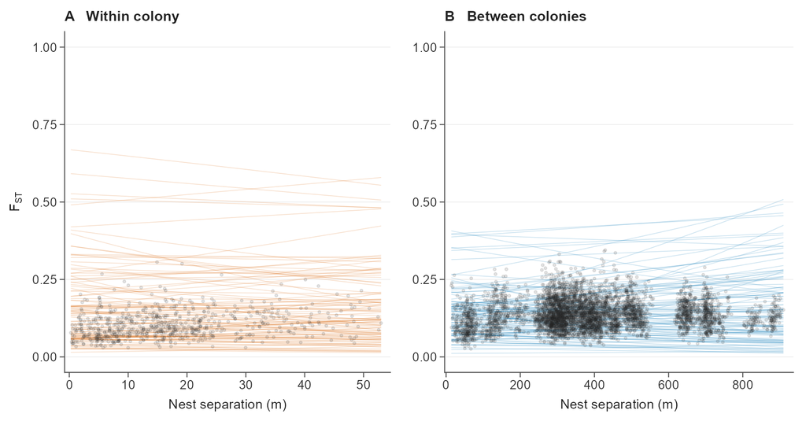

100 prior-drawn response curves per panel; points are observations for reference. Group-specific deviations are zero. Curves show expected responses without observation noise; their full vertical range is shown. Observed outcomes were not used to generate the curves or revise the priors.

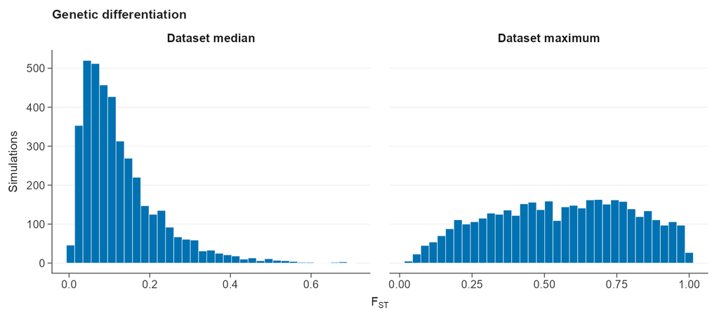

4000 simulations include all group effects and response noise, using 800 evenly spaced design rows. Each value summarises one simulated dataset.

Genetic differentiation prior tail probabilities, as percentages

| group | FST < 0.001 (%) | FST > 0.5 (%) | FST > 0.9 (%) |
| --- | --- | --- | --- |
| Between | 0.0386 | 3.3061 | 0.0589 |
| Within | 0.2108 | 6.5732 | 0.2747 |

```r
# Expected-response curves: 100 draws, with group deviations set to zero.
set.seed(seed + 702L)
draws <- 100L
model_data <- model_specs$m1$data
prior_settings <- model_specs$m1$prior_parameters
intercept_draws <- rnorm(draws, prior_settings$intercept[1], prior_settings$intercept[2])
same_colony_draws <- rnorm(draws, 0, prior_settings$same_colony)
between_distance_draws <- rnorm(draws, 0, prior_settings$between_slope)
within_distance_draws <- rnorm(draws, 0, prior_settings$within_slope)
log_residual_sd_draws <- rnorm(draws, prior_settings$log_sigma[1], prior_settings$log_sigma[2])
log_residual_sd_contrast_draws <- rnorm(draws, 0, prior_settings$sigma_contrast)
genetic_prior_curves <- setNames(lapply(c(1L, 0L), function(within) {
  x <- seq(min(model_data$distance_m[model_data$same_colony == within]),
    max(model_data$distance_m[model_data$same_colony == within]), length.out = 80L)
  linear_predictor_draws <- intercept_draws + same_colony_draws * within +
    outer(if (within == 1L) within_distance_draws else between_distance_draws, (x - 50) / 100)
  residual_sd_draws <- exp(log_residual_sd_draws + log_residual_sd_contrast_draws * within)
  long_prior_draws(x, prior_mean_fst(linear_predictor_draws, residual_sd_draws))
}), c("Within colony", "Between colonies"))
panels <- lapply(seq_along(genetic_prior_curves), function(j) {
  observed_data <- model_data[model_data$same_colony == as.integer(j == 1L), ]
  plot <- ggplot(genetic_prior_curves[[j]], aes(x, y, group = draw)) +
    geom_line(colour = unname(figure_colours[j]), alpha = .2, linewidth = .22) +
    geom_point(data = tibble(x = observed_data$distance_m, y = observed_data$FST_Latter), aes(x, y),
      inherit.aes = FALSE, colour = "#222222", alpha = .12, size = .6)
  style_prior_panel(plot, "distance_m", j, genetic = TRUE, investment = FALSE, y_range = c(0, 1))
})
plot <- arrange_panels(panels, width = 180, height = 94)
save_figure("m1_prior_trends", plot, width = 180, height = 94)
show_figure("m1_prior_trends", paste0(
  "100 prior-drawn response curves per panel; points are observations for reference. ",
  "Group-specific deviations are zero. ",
  "Curves show expected responses without observation noise; their full vertical range is shown. ",
  "Observed outcomes were not used to generate the curves or revise the priors."))

# Full prior predictions include shared group effects and observation noise.
set.seed(seed + 20L)
genetic_prior_simulation <- simulate_genetic_prior(model_specs$m1, draws = 4000L)
replicated_outcomes <- genetic_prior_simulation$yrep
genetic_prior_summary <- tibble(`Dataset median` = apply(replicated_outcomes, 1, median),
  `Dataset maximum` = apply(replicated_outcomes, 1, max))
prior_summary_long <- genetic_prior_summary |> pivot_longer(everything(), names_to = "statistic", values_to = "value") |>
  mutate(statistic = factor(statistic, levels = names(genetic_prior_summary)))
plot <- ggplot(prior_summary_long, aes(value)) +
  geom_histogram(bins = 35, fill = "#0072B2", colour = "white", linewidth = .15) +
  facet_wrap(~statistic, scales = "free_x") +
  labs(x = expression(F[ST]), y = "Simulations", title = model_label("m1"))
save_figure("m1_prior", plot, width = 180, height = 80)
show_figure("m1_prior", paste(4000,
  "simulations include all group effects and response noise, using", nrow(genetic_prior_simulation$data),
  "evenly spaced design rows. Each value summarises one simulated dataset."))
groups <- ifelse(genetic_prior_simulation$data$same_colony == 1, "Within", "Between")
genetic_prior_tails <- imap_dfr(split(seq_len(ncol(replicated_outcomes)), groups), function(ii, group) {
  tibble(group = group, `FST < 0.001 (%)` = 100 * mean(replicated_outcomes[, ii] < .001),
    `FST > 0.5 (%)` = 100 * mean(replicated_outcomes[, ii] > .5), `FST > 0.9 (%)` = 100 * mean(replicated_outcomes[, ii] > .9))
})
show_table(genetic_prior_tails, digits = 4,
  caption = paste(model_label("m1"), "prior tail probabilities, as percentages"))
```

## Fit and check the model

`brm()` fits the model; the next chunk checks sampling.

```r
sampling_dir <- tempfile("wood-ant-sampling-")
dir.create(sampling_dir)
model_fits$m1 <- brm(
  formula = model_specs$m1$formula, data = model_specs$m1$data,
  family = model_specs$m1$family, prior = model_specs$m1$prior,
  backend = "cmdstanr", chains = 4, cores = 4,
  iter = 3000L, warmup = 2000L, seed = 20261021L, init = 0,
  control = list(adapt_delta = .99, max_treedepth = 13, metric = "diag_e"),
  save_pars = save_pars(all = TRUE), output_dir = sampling_dir,
  refresh = 200, silent = 1
)
model_fits$m1 <- refine_sampling_fit(model_fits$m1, 20261021L, sampling_dir)
# Collect more draws if convergence remains inadequate after refinement.
if (!diagnose_fit(model_fits$m1, "m1")$pass) {
  initial_depth_hits <- attr(model_fits$m1, "initial_depth_hits")
  sampler_metadata <- attr(model_fits$m1$fit, "metadata")
  sampling_dir <- tempfile("wood-ant-sampling-")
  dir.create(sampling_dir)
  model_fits$m1 <- update(model_fits$m1,
    backend = "cmdstanr", cores = 4,
    iter = 2500L, warmup = 500L, seed = 20261023L, init = 0,
    inv_metric = sampler_metadata$inv_metric, step_size = unlist(sampler_metadata$step_size),
    control = list(adapt_delta = .99, max_treedepth = 14, metric = "diag_e",
      init_buffer = 0L, window = 0L, term_buffer = 500L),
    output_dir = sampling_dir, refresh = 250, silent = 1
  )
  attr(model_fits$m1, "initial_depth_hits") <- initial_depth_hits
  unlink(sampling_dir, recursive = TRUE)
}
```

```r
genetic_diagnostics <- diagnose_fit(model_fits$m1, "m1")
show_table(genetic_diagnostics)
stopifnot(all(genetic_diagnostics$pass))
```

| model | max_rhat | min_ess_bulk | min_ess_tail | divergences | initial_divergences | initial_depth_hits | treedepth_hits | max_treedepth | min_ebfmi | pass |
| --- | --- | --- | --- | --- | --- | --- | --- | --- | --- | --- |
| m1 | 1.005 | 1085.342 | 2282.684 | 0 | 0 | 1 | 0 | 14 | 0.619 | TRUE |

## Results

For each posterior draw, we calculated average FST predicted by the model on its original scale, accounting for the different residual variation within and between colonies.

### Main comparison: shared range with group-specific deviations set to zero

For Model 1, we used distance-standardised predictions with group-specific deviations set to zero. Both categories used the same 201 equally spaced midpoints across their shared range (approximately 14.0–53.0 m), with equal weights. Within each posterior draw, we averaged mean FST and local slopes separately for each category, then calculated the within-minus-between contrasts. The first table reports mean FST and its contrast; the second reports average marginal effects in FST per metre and their contrast. All 5,460 pairs remain in the fitted model.

```r
check_prediction_integration()
model_data <- model_specs$m1$data
groups <- c("Within colony", "Between colonies")
ranges <- vapply(c(1L, 0L), function(g) range(model_data$distance_m[model_data$same_colony == g]), numeric(2))
shared_range <- c(low = max(ranges[1, ]), high = min(ranges[2, ]))
grid_size <- 201L
derivative_step <- .01
range_width <- diff(shared_range)
stopifnot(grid_size >= 2L, range_width > 0, derivative_step > 0, derivative_step < range_width / (2 * grid_size))
# Equally weighted midpoints keep the derivative steps inside the shared range.
distance_grid <- shared_range[1] + (seq_len(grid_size) - .5) * range_width / grid_size
genetic_result_draw_ids <- seq_len(ndraws(model_fits$m1))
mean_response_draws <- mean_slope_draws <- matrix(0, length(genetic_result_draw_ids), 2L, dimnames = list(NULL, groups))
for (g in seq_along(groups)) {
  ix <- which(model_data$same_colony == as.integer(g == 1L))[1]
  newdata <- model_data[rep(ix, grid_size), , drop = FALSE]
  newdata <- shift_genetic_distance(newdata, distance_grid - newdata$distance_m)
  # Integrate residual variation to obtain expected FST; group deviations are zero.
  expected_draws <- expected_response(model_fits$m1, model_specs$m1, newdata, re_formula = NA, draw_ids = genetic_result_draw_ids)
  lower_predictions <- expected_response(model_fits$m1, model_specs$m1, shift_genetic_distance(newdata, -derivative_step),
    re_formula = NA, draw_ids = genetic_result_draw_ids)
  upper_predictions <- expected_response(model_fits$m1, model_specs$m1, shift_genetic_distance(newdata, derivative_step),
    re_formula = NA, draw_ids = genetic_result_draw_ids)
  mean_response_draws[, g] <- rowMeans(expected_draws)
  mean_slope_draws[, g] <- rowMeans((upper_predictions - lower_predictions) / (2 * derivative_step))
}
# Average and contrast within each draw before taking posterior means and intervals.
quantities <- tibble(Quantity = c(groups, "Within minus between"))
level_estimates <- bind_cols(quantities,
  summarize_columns(cbind(mean_response_draws, mean_response_draws[, 1] - mean_response_draws[, 2])))
estimates <- bind_cols(quantities,
  summarize_columns(cbind(mean_slope_draws, mean_slope_draws[, 1] - mean_slope_draws[, 2])))
genetic_shared_range_results <- list(shared_range = shared_range,
  slopes = mean_slope_draws, estimates = estimates, levels = mean_response_draws, level_estimates = level_estimates)
show_genetic_results(genetic_shared_range_results)
```

Distance-standardised mean FST and its contrast (shared range: 14.0–53.0 m)

| Quantity | FST (95% credible interval) |
| --- | --- |
| Mean FST: within colony | 0.0986 (0.0833 to 0.1162) |
| Mean FST: between colonies | 0.1302 (0.1112 to 0.1518) |
| FST contrast: within minus between | -0.0316 (-0.0490 to -0.0154) |

Average local distance slopes and their contrast (shared range: 14.0–53.0 m)

| Quantity | FST per m (95% credible interval) |
| --- | --- |
| Mean slope: within colony | 0.00018 (-0.00004 to 0.00043) |
| Mean slope: between colonies | 0.00002 (-0.00001 to 0.00005) |
| Slope contrast: within minus between | 0.00016 (-0.00006 to 0.00041) |

The figure shows posterior prediction curves over the full distance range and where the ranges overlap.

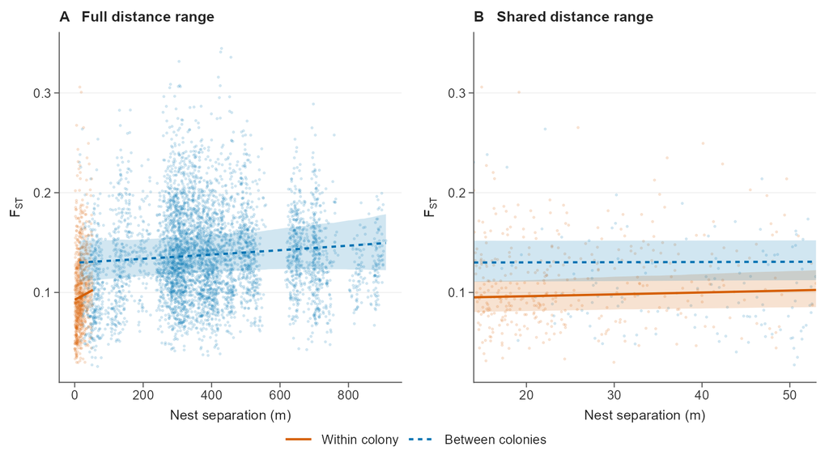

Points show observations; distances use local maps within colonies and GPS between colonies. Posterior prediction curves show mean FST with group-specific deviations set to zero, with posterior means and 95% credible intervals. Each curve stops at its category’s observed distance limits; the zoom shows the same curves.  
Files: genetic_differentiation_by_distance.svg · genetic_differentiation_by_distance.png

```r
model_data <- model_specs$m1$data
colony_groups <- c("Within colony", "Between colonies")
group <- ifelse(model_data$same_colony == 1, colony_groups[1], colony_groups[2])
genetic_curve_draw_ids <- unique(round(seq(1, ndraws(model_fits$m1), length.out = min(2000, ndraws(model_fits$m1)))))
genetic_curves <- lapply(colony_groups, function(g) {
  ix <- which(group == g)
  distance_grid <- seq(min(model_data$distance_m[ix]), max(model_data$distance_m[ix]), length.out = 100)
  newdata <- model_data[rep(ix[1], length(distance_grid)), , drop = FALSE]
  newdata <- shift_genetic_distance(newdata, distance_grid - newdata$distance_m)
  # Expected FST integrates over residual variation; group deviations are zero.
  linear_predictor_draws <- posterior_linpred(model_fits$m1, newdata = newdata, re_formula = NA, draw_ids = genetic_curve_draw_ids)
  residual_sd_draws <- posterior_linpred(model_fits$m1, newdata = newdata, dpar = "sigma",
    transform = TRUE, re_formula = NA, draw_ids = genetic_curve_draw_ids)
  predictions <- mean_fst(linear_predictor_draws, residual_sd_draws)
  bind_cols(tibble(group = g, distance_m = distance_grid), summarize_columns(predictions))
}) |> bind_rows() |> mutate(group = factor(group, levels = colony_groups))
genetic_observations <- tibble(group = factor(group, levels = colony_groups),
  distance_m = model_data$distance_m, observed = model_data$FST_Latter)
ranges <- genetic_observations |> group_by(group) |>
  summarise(low = min(distance_m), high = max(distance_m), .groups = "drop")
shared_range <- c(low = max(ranges$low), high = min(ranges$high))

plot <- ggplot() +
  geom_point(data = genetic_observations, aes(distance_m, observed, colour = group),
    alpha = .13, size = .4, show.legend = FALSE) +
  geom_ribbon(data = genetic_curves,
    aes(distance_m, ymin = lower, ymax = upper, fill = group), alpha = .18, colour = NA) +
  geom_line(data = genetic_curves, aes(distance_m, estimate, colour = group,
    linetype = group), linewidth = .65)
plot <- style_genetic_plot(plot, colony_groups)
panels <- list(plot + labs(title = "A   Full distance range"),
  plot + coord_cartesian(xlim = shared_range,
    expand = c(bottom = TRUE, left = FALSE, top = TRUE, right = FALSE)) +
    labs(title = "B   Shared distance range"))
genetic_figure <- arrange_panels(panels, width = 180, height = 98, legend_plot = plot)
save_figure("m1_distance_comparison", genetic_figure, width = 180, height = 98)
show_figure("m1_distance_comparison", paste0(
  "Points show observations; distances use local maps within colonies and GPS between colonies. ",
  "Posterior prediction curves show mean FST with group-specific deviations set to zero, ",
  "with posterior means and 95% credible intervals. ",
  "Each curve stops at its category's observed distance limits; the zoom shows the same curves."))
```

We set group-specific deviations to zero because 42 of 45 between-colony combinations have no observations in the shared range. This avoids extrapolating their fitted deviations and compares the overall modelled relationships.

**Interpretation.** Over the shared distance range, average FST predicted by the model with group-specific deviations set to zero was lower within colonies (0.0986; 95% credible interval 0.0833–0.1162) than between colonies (0.1302; 0.1112–0.1518). The distance-standardised within-minus-between contrast was −0.0316 (95% credible interval −0.0490 to −0.0154).

Over the same range, the within-colony slope was positive on average but uncertain (average local slope 0.00018 FST per metre; 95% credible interval −0.00004 to 0.00043). Between colonies, the slope was small and its direction uncertain (0.00002 FST per metre; 95% credible interval −0.00001 to 0.00005). The within-minus-between slope contrast was also uncertain (0.00016 FST per metre; 95% credible interval −0.00006 to 0.00041).

### Additional description: full range for the sampled pairs

These results use each category’s full observed distance range, retaining fitted nest, colony and colony-pair effects (rather than comparing over the shared distance range, requiring the group effects to be held at zero).

```r
model_data <- model_specs$m1$data
groups <- c("Within colony", "Between colonies")
group <- ifelse(model_data$same_colony == 1, groups[1], groups[2])
genetic_full_range_draw_ids <- seq_len(ndraws(model_fits$m1))
derivative_step <- .01
# Sum over every observed pair in batches, retaining its fitted group effects.
prediction_sums <- genetic_row_sums(model_fits$m1, model_specs$m1, derivative_step = derivative_step,
  draw_ids = genetic_full_range_draw_ids, re_formula = NULL)
counts <- vapply(groups, function(g) sum(group == g), integer(1))
mean_response_draws <- sweep(prediction_sums$level_sums, 2, counts, "/")
mean_slope_draws <- sweep(prediction_sums$slope_sums, 2, counts, "/")
quantities <- tibble(Quantity = c(groups, "Within minus between"),
  Pairs = c(unname(counts), NA_integer_))
level_estimates <- bind_cols(quantities,
  summarize_columns(cbind(mean_response_draws, mean_response_draws[, 1] - mean_response_draws[, 2])))
estimates <- bind_cols(quantities,
  summarize_columns(cbind(mean_slope_draws, mean_slope_draws[, 1] - mean_slope_draws[, 2])))
genetic_full_range_results <- list(slopes = mean_slope_draws, estimates = estimates,
  levels = mean_response_draws, level_estimates = level_estimates)
```

**Interpretation.** Average FST predicted by the model was lower within colonies (0.1045; 95% credible interval 0.1020–0.1071) than between colonies (0.1376; 0.1368–0.1384). The within-minus-between contrast was −0.0331 (95% credible interval −0.0357 to −0.0304).

Over these full ranges, the within-colony slope was positive on average but uncertain (average local slope 0.00019 FST per metre; 95% credible interval −0.00004 to 0.00043). Between colonies, the slope was small and its direction uncertain (−0.00004 FST per metre; 95% credible interval −0.00011 to 0.00003). The within-minus-between slope contrast was also uncertain (0.00023 FST per metre; 95% credible interval −0.00001 to 0.00047).

## Posterior predictive checks

```r
set.seed(seed + 100L)
model_data <- model_specs$m1$data
draw_ids <- unique(round(seq(1, ndraws(model_fits$m1), length.out = 400)))
# Replicate the fitted rows, retaining fitted group effects and response noise.
replicated_outcomes <- posterior_predict(model_fits$m1, re_formula = NULL, draw_ids = draw_ids)
observed_outcomes <- plogis(model_data$response)
replicated_outcomes <- plogis(replicated_outcomes)
predictive_checks$m1 <- posterior_predictive_summary(observed_outcomes, replicated_outcomes, "m1",
  list(minimum = min, median = median, maximum = max, sd = sd))
# Check distance quartiles separately within and between colonies.
bins <- model_data |>
  mutate(category = ifelse(same_colony, "Within", "Between")) |>
  group_by(category) |>
  mutate(bin = ntile(distance_m, 4)) |>
  ungroup()
strata <- list(distance = paste(bins$category, "distance quartile", bins$bin))
show_table(posterior_group_checks(observed_outcomes, replicated_outcomes, strata),
  caption = "Posterior predictive checks of group means")
show_table(predictive_checks$m1, digits = 4)
```

Posterior predictive checks of group means

| Grouping | Groups checked | Outside 95% predictive interval |
| --- | --- | --- |
| Distance quartile | 8 | 0 |

| model | statistic | observed | lower_rep | median_rep | upper_rep | probability_rep_above_observed |
| --- | --- | --- | --- | --- | --- | --- |
| m1 | minimum | 0.0258 | 0.0181 | 0.0253 | 0.0319 | 0.4575 |
| m1 | median | 0.1291 | 0.1257 | 0.1269 | 0.1284 | 0.0025 |
| m1 | maximum | 0.3446 | 0.3434 | 0.3809 | 0.4423 | 0.9675 |
| m1 | sd | 0.0465 | 0.0470 | 0.0482 | 0.0493 | 0.9950 |

Observed and replicated residuals use the same posterior draw of the mean and scale. The table gives median observed skewness and the probability that replicated skewness is larger.

| model | group | statistic | observed | lower | estimate | upper | probability_rep_above |
| --- | --- | --- | --- | --- | --- | --- | --- |
| m1 | Between | minimum | 0.0258 | 0.0303 | 0.0382 | 0.0434 | 0.995 |
| m1 | Between | median | 0.1331 | 0.1292 | 0.1307 | 0.1322 | 0.000 |
| m1 | Between | maximum | 0.3446 | 0.3418 | 0.3751 | 0.4347 | 0.960 |
| m1 | Between | sd | 0.0454 | 0.0459 | 0.0471 | 0.0483 | 1.000 |
| m1 | Between | skewness | 0.5803 | 0.7457 | 0.8327 | 0.9370 | 1.000 |
| m1 | Between | residual_skewness | -0.9764 | -0.0631 | 0.0032 | 0.0739 | 1.000 |
| m1 | Within | minimum | 0.0298 | 0.0178 | 0.0256 | 0.0317 | 0.095 |
| m1 | Within | median | 0.0952 | 0.0916 | 0.0957 | 0.1003 | 0.585 |
| m1 | Within | maximum | 0.3059 | 0.2656 | 0.3189 | 0.4227 | 0.680 |
| m1 | Within | sd | 0.0434 | 0.0424 | 0.0461 | 0.0498 | 0.910 |
| m1 | Within | skewness | 1.0101 | 0.8673 | 1.1136 | 1.5526 | 0.745 |
| m1 | Within | residual_skewness | -0.7855 | -0.1840 | 0.0042 | 0.1703 | 1.000 |

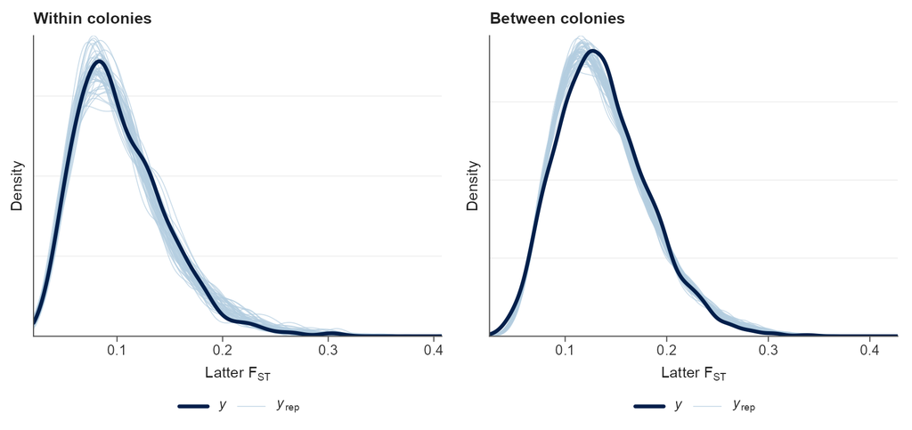

Observed FST distributions (dark lines) and posterior replications (light lines), within and between colonies.

```r
set.seed(seed + 402L)
model_data <- model_specs$m1$data
draw_ids <- unique(round(seq(1, ndraws(model_fits$m1), length.out = 400L)))
replicated_logit_fst <- posterior_predict(model_fits$m1, re_formula = NULL, draw_ids = draw_ids)
linear_predictor_draws <- posterior_linpred(model_fits$m1, re_formula = NULL, draw_ids = draw_ids)
residual_sd_draws <- posterior_linpred(model_fits$m1, dpar = "sigma", transform = TRUE,
  re_formula = NULL, draw_ids = draw_ids)
genetic_distribution <- genetic_predictive_summary(replicated_logit_fst, linear_predictor_draws, residual_sd_draws, model_data, "m1")
observed_outcomes <- plogis(model_data$response)
replicated_outcomes <- plogis(replicated_logit_fst)
groups <- split(seq_len(nrow(model_data)), ifelse(model_data$same_colony == 1, "Within", "Between"))
plots <- imap(groups, function(ii, group) {
  bayesplot::ppc_dens_overlay(observed_outcomes[ii], replicated_outcomes[seq_len(min(50, nrow(replicated_outcomes))), ii, drop = FALSE]) +
    labs(title = paste(group, "colonies"), x = expression("Latter " * F[ST]), y = "Density")
})
plot <- arrange_panels(plots[c("Within", "Between")], width = 180, height = 85, align_widths = TRUE)
save_figure("m1_ppc_distributions", plot, width = 180, height = 85)
show_table(genetic_distribution, digits = 4)
show_figure("m1_ppc_distributions",
  "Observed FST distributions (dark lines) and posterior replications (light lines), within and between colonies.")
```

# Model 2: Trail presence

**Question and interpretation.** How does trail probability vary with distance, genetic differentiation and food difference within colonies? Including present and absent trails avoids selection on presence. Food difference is biologically motivated but not an established confounder. Genetic differentiation could influence trail formation or record past connectivity. If it mediates a distance effect, adjusting for it blocks that pathway: the distance association would not estimate a total causal effect.

**Data.** There are 645 within-colony pairs from 104 nests in ten colonies: 84 observed trails and 561 confirmed absences. Of 662 screened within-colony pairs, 17 were excluded because one nest lacked the population estimate needed for the food predictor. No additional pairs were excluded for other missing measurements.

## Shared definitions for the trail models

Both trail models use screened within-colony pairs; 4,798 between-colony pairs are outside their scope, leaving 662 pairs before measurement exclusions. $T_i$ indicates trail presence; unlisted trails are absences only in the completely surveyed colonies. Let $Q_j$ be nest $j$’s summed outgoing foraging strength (ants/cm) and $N_j$ its estimated population (ants). Monitored nests without foraging trails have zero observed income. Food difference and investment are defined in the data processing code:

$$H_i=\left|\frac{Q_{a_i}}{N_{a_i}}-\frac{Q_{b_i}}{N_{b_i}}\right|,
\qquad
I_i=\frac{\lambda_i L_i}{(N_{a_i}+N_{b_i})/2},$$

where $\lambda_i$ is trail strength (ants/cm) and $L_i$ local straight-line length (cm). $H_i$ has units cm$^{-1}$; $I_i$ is dimensionless but not bounded as a literal population fraction. Investment requires observed trails with finite positive investment and nest sizes. Both trail models use local-map separation as the distance predictor, so $D_i=L_i/100$ in metres.

Superscripts $P$ and $I$ distinguish the models’ separate parameters. In each, $u_j$ is a multiple-membership nest intercept, summed over both nests, and $c_{0,k}$ and $c_{D,k}$ describe colony baseline and distance effects. The pair’s shared colony is $k(i)=c(a_i)=c(b_i)$. Indices cover retained nests and all ten colonies. Nest and colony effects are independent conditional on their population parameters.

$\Sigma_P$ and $\Sigma_I$ are the colony deviations’ covariance matrices; $\mathbf R_P$ and $\mathbf R_I$ are their correlation matrices. These are correlated colony random effects: baseline and log decline magnitude in Model 2, and baseline and distance slope in Model 3.

```r
trail_transformations <- make_trail_transformations(processed_data$analysis_data)
show_table(trail_transformations, digits = 6, caption = "Shared trail-predictor transformations")
```

Shared trail-predictor transformations

| variable | center | scale |
| --- | --- | --- |
| distance_m | 20.154058 | 13.676321 |
| FST_Latter | 0.100082 | 0.037989 |
| food_difference | 0.000059 | 0.000109 |

## Model formulation

For every eligible surveyed within-colony pair,

$$\begin{aligned}
T_i &\sim \operatorname{Bernoulli}(p_i),\\
\operatorname{logit}(p_i) &=
\alpha_P+b_{D,k(i)}^{(P)}z_{D,i}+b_{F,P}z_{F,i}+b_{H,P}z_{H,i}\\
&\quad+u_{a_i}^{(P)}+u_{b_i}^{(P)}+c_{0,k(i)}^{(P)},\\
b_{D,k}^{(P)} &= -m_P\exp(c_{D,k}^{(P)}),\\
u_j^{(P)} &\sim \operatorname{Normal}(0,\tau_{u,P}),\\
\begin{bmatrix}c_{0,k}^{(P)}\\c_{D,k}^{(P)}\end{bmatrix}
&\sim
\operatorname{MVNormal}\!\left(\begin{bmatrix}0\\0\end{bmatrix},\Sigma_P\right),\\
\alpha_P &\sim \operatorname{Normal}(-2,1.5),\\
m_P &\sim \operatorname{HalfNormal}(0,3),\\
b_{F,P},b_{H,P} &\sim \operatorname{Normal}(0,1),\\
\tau_{u,P},\tau_{0,P},\tau_{D,P} &\sim
\operatorname{Exponential}(2),\\
\Sigma_P &= \operatorname{diag}(\tau_{0,P},\tau_{D,P})\,
\mathbf R_P\,\operatorname{diag}(\tau_{0,P},\tau_{D,P}),\\
\mathbf R_P &\sim \operatorname{LKJCorr}(2).
\end{aligned}$$

Here $m_P$ is the shared decline magnitude. The positive multiplier $\exp(c_{D,k}^{(P)})$ lets the decline rate vary among colonies while keeping every colony’s distance slope non-positive.

Between-colony pairs do not enter as structural absences.

## Specify the model

```r
presence_data <- apply_trail_scales(analysis_data$m2, trail_transformations)
presence_prior_settings <- list(
  intercept = c(-2, 1.5), slope_sd = 1, distance_sd = 3,
  genetic_sd = 1, food_sd = 1, group_rate = 2, correlation = 2
)
presence_data$response <- as.integer(presence_data$connected)
stopifnot(setequal(unique(presence_data$response), c(0, 1)))

# Every colony's distance slope is -distanceDecline * exp(logColonyMultiplier).
# Baseline log odds include genetic, food, nest and colony effects.
# Colony baselines and log steepness can covary; nest effects are summed.
presence_formula <- bf(
  response ~ baselineLogOdds - distanceDecline * exp(logColonyMultiplier) * distance_z,
  baselineLogOdds ~ 0 + Intercept + fst_z + food_z + (1 | colonyEffects | colony) +
    (1 | mm(from_label, to_label, weights = cbind(w1, w2), scale = FALSE)),
  distanceDecline ~ 1,
  logColonyMultiplier ~ 0 + (1 | colonyEffects | colony), nl = TRUE)
presence_priors <- c(
  set_prior(normal_prior(presence_prior_settings$intercept[1], presence_prior_settings$intercept[2]),
    class = "b", coef = "Intercept", nlpar = "baselineLogOdds"),
  set_prior(normal_prior(0, presence_prior_settings$genetic_sd), class = "b", coef = "fst_z", nlpar = "baselineLogOdds"),
  set_prior(normal_prior(0, presence_prior_settings$food_sd), class = "b", coef = "food_z", nlpar = "baselineLogOdds"),
  set_prior(normal_prior(0, presence_prior_settings$distance_sd), class = "b", nlpar = "distanceDecline", lb = 0),
  set_prior(sprintf("exponential(%g)", presence_prior_settings$group_rate), class = "sd", nlpar = "baselineLogOdds"),
  set_prior(sprintf("exponential(%g)", presence_prior_settings$group_rate), class = "sd", nlpar = "logColonyMultiplier"),
  set_prior(sprintf("lkj(%g)", presence_prior_settings$correlation), class = "cor")
)
model_specs$m2 <- list(
  name = "m2", formula = presence_formula, data = presence_data, prior = presence_priors, prior_parameters = presence_prior_settings,
  family = bernoulli("logit"), response_scale = "bernoulli"
)
model_specs$m2$formula
```

```
response ~ baselineLogOdds - distanceDecline * exp(logColonyMultiplier) * distance_z
baselineLogOdds ~ 0 + Intercept + fst_z + food_z + (1 | colonyEffects | colony) + (1 | mm(from_label, to_label, weights = cbind(w1, w2), scale = FALSE))
distanceDecline ~ 1
logColonyMultiplier ~ 0 + (1 | colonyEffects | colony)
```

## Priors and prior predictions

We assumed that greater distance cannot increase trail probability within a colony, reflecting the costs of maintaining longer connections. The half-normal prior on decline magnitude peaks at zero; scale 3 allows weak through steep declines in prior predictions. Direction is assumed, so inference concerns the size of the decline. The baseline prior favours sparse networks; exponential SD priors regularise nest and colony variation, and LKJ(2) mildly favours correlations near zero.

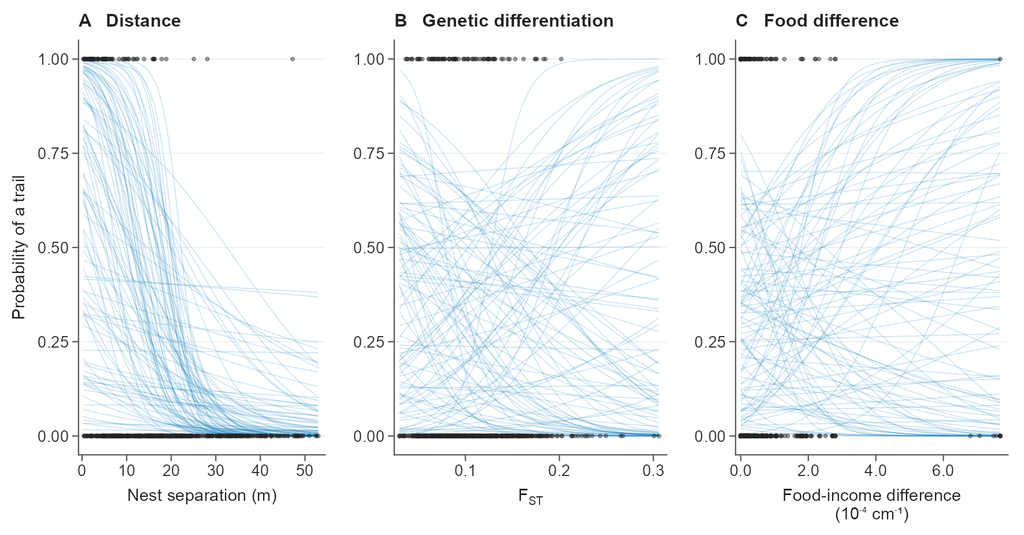

100 prior-drawn response curves per panel; points are observations for reference. Group-specific deviations are zero. Other predictors retain their observed values, averaged over the same pairs at every grid point. Curves show expected responses without observation noise; their full vertical range is shown. Observed outcomes were not used to generate the curves or revise the priors.

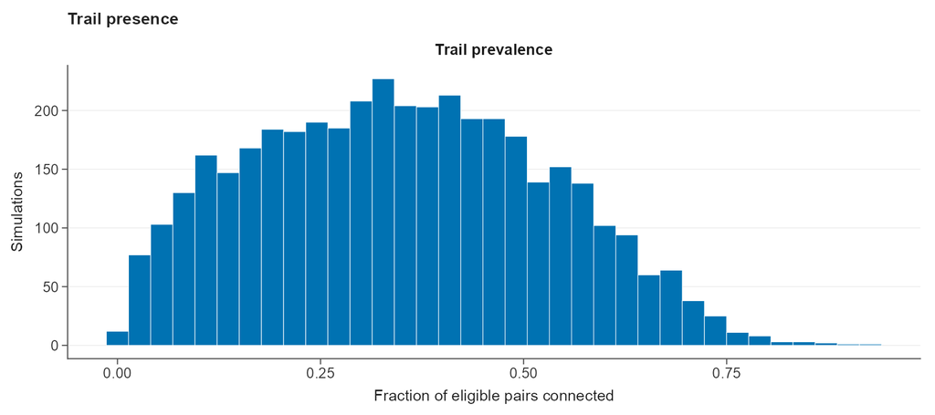

4000 simulations include all group effects and response noise, using 645 evenly spaced design rows. Each value summarises one simulated dataset.

```r
# Expected-response curves: 100 draws, with group deviations set to zero.
set.seed(seed + 703L)
draws <- 100L
model_data <- model_specs$m2$data
prior_settings <- model_specs$m2$prior_parameters
intercept_draws <- rnorm(draws, prior_settings$intercept[1], prior_settings$intercept[2])
coefficient_draws <- cbind(rnorm(draws, 0, prior_settings$slope_sd), rnorm(draws, 0, prior_settings$genetic_sd),
  rnorm(draws, 0, prior_settings$food_sd))
# The distance effect is non-positive, with most prior weight near zero.
coefficient_draws[, 1] <- -abs(coefficient_draws[, 1]) * prior_settings$distance_sd / prior_settings$slope_sd
variables <- c("distance_m", "FST_Latter", "food_difference")
standardized_predictors <- as.matrix(model_data[, c("distance_z", "fst_z", "food_z")])
presence_prior_curves <- setNames(lapply(seq_along(variables), function(j) {
  x <- seq(min(model_data[[variables[j]]]), max(model_data[[variables[j]]]), length.out = 80L)
  predictor_scaling <- trail_transformations[match(variables[j], trail_transformations$variable), ]
  grid_z <- (x - predictor_scaling$center) / predictor_scaling$scale
  other_predictor_contribution <- intercept_draws + coefficient_draws[, -j, drop = FALSE] %*% t(standardized_predictors[, -j, drop = FALSE])
  y <- vapply(grid_z, function(value) {
    linear_predictor_draws <- other_predictor_contribution + coefficient_draws[, j] * value
    rowMeans(plogis(linear_predictor_draws))
  }, numeric(draws))
  long_prior_draws(x, y)
}), variables)
y_range <- c(0, 1)
panels <- lapply(seq_along(variables), function(j) {
  variable <- variables[j]
  plot <- ggplot(presence_prior_curves[[j]], aes(x, y, group = draw)) +
    geom_line(colour = "#0072B2", alpha = .2, linewidth = .22) +
    geom_point(data = tibble(x = model_data[[variable]], y = model_data$response), aes(x, y),
      inherit.aes = FALSE, colour = "#222222", alpha = .4, size = .6)
  style_prior_panel(plot, variable, j, genetic = FALSE, investment = FALSE, y_range = y_range)
})
plot <- arrange_panels(panels, width = 180, height = 94)
save_figure("m2_prior_trends", plot, width = 180, height = 94)
show_figure("m2_prior_trends", paste0(
  "100 prior-drawn response curves per panel; points are observations for reference. ",
  "Group-specific deviations are zero. ",
  "Other predictors retain their observed values, averaged over the same pairs at every grid point. ",
  "Curves show expected responses without observation noise; their full vertical range is shown. ",
  "Observed outcomes were not used to generate the curves or revise the priors."))

# Full prior predictions include shared group effects and observation noise.
set.seed(seed + 22L)
presence_prior_simulation <- simulate_prior(model_specs$m2, draws = 4000L)
replicated_outcomes <- presence_prior_simulation$yrep
presence_prior_summary <- tibble(`Trail prevalence` = rowMeans(replicated_outcomes))
prior_summary_long <- presence_prior_summary |> pivot_longer(everything(), names_to = "statistic", values_to = "value") |>
  mutate(statistic = factor(statistic, levels = names(presence_prior_summary)))
plot <- ggplot(prior_summary_long, aes(value)) +
  geom_histogram(bins = 35, fill = "#0072B2", colour = "white", linewidth = .15) +
  facet_wrap(~statistic, scales = "free_x") +
  labs(x = "Fraction of eligible pairs connected", y = "Simulations", title = model_label("m2"))
save_figure("m2_prior", plot, width = 180, height = 80)
show_figure("m2_prior", paste(4000,
  "simulations include all group effects and response noise, using", nrow(presence_prior_simulation$data),
  "evenly spaced design rows. Each value summarises one simulated dataset."))
```

## Fit and check the model

`brm()` fits the model; the next chunk checks sampling.

```r
sampling_dir <- tempfile("wood-ant-sampling-")
dir.create(sampling_dir)
model_fits$m2 <- brm(
  formula = model_specs$m2$formula, data = model_specs$m2$data,
  family = model_specs$m2$family, prior = model_specs$m2$prior,
  backend = "cmdstanr", chains = 4, cores = 4,
  iter = 5000L, warmup = 2000L, seed = 20261021L, init = NULL,
  control = list(adapt_delta = .995, max_treedepth = 13, metric = "diag_e"),
  save_pars = save_pars(all = TRUE), output_dir = sampling_dir,
  refresh = 200, silent = 1
)
model_fits$m2 <- refine_sampling_fit(model_fits$m2, 20261021L, sampling_dir)
```

```r
presence_diagnostics <- diagnose_fit(model_fits$m2, "m2")
show_table(presence_diagnostics)
stopifnot(all(presence_diagnostics$pass))
```

| model | max_rhat | min_ess_bulk | min_ess_tail | divergences | initial_divergences | initial_depth_hits | treedepth_hits | max_treedepth | min_ebfmi | pass |
| --- | --- | --- | --- | --- | --- | --- | --- | --- | --- | --- |
| m2 | 1.002 | 4319.088 | 5154.436 | 0 | 0 | 0 | 0 | 13 | 0.931 | TRUE |

## Results

Trail effect tables instead average local slopes at every analysed pair’s observed predictor values, retaining its other predictors and fitted group effects and giving each pair equal weight within each posterior draw.

Trail effects use all 645 presence pairs and all 84 existing trails for investment. We report local rates per metre, per 0.01 FST and per 0.0001/cm food difference, in percentage points for presence and the dimensionless investment index for investment. These units rescale slopes; they do not imply finite changes of those sizes. Results describe adjusted associations for the sampled pairs.

The table reports average marginal effects on trail probability, in percentage points per stated predictor unit. Positive values indicate a local increase; zero indicates no local association. The distance-band table shows where probability falls most rapidly.

```r
model_data <- model_specs$m2$data
presence_result_draw_ids <- seq_len(ndraws(model_fits$m2))
ame_settings <- tibble(
  variable = c("distance_m", "FST_Latter", "food_difference"),
  unit = c(1, .01, .0001), derivative_step = c(.01, 1e-5, 1e-7),
  label = c("Distance (per m)", "FST (per 0.01)", "Food-income difference (per 0.0001/cm)")
)
# Local response-scale slopes retain every observed pair and its fitted group effects.
presence_marginal_effect_draws <- lapply(seq_len(nrow(ame_settings)), function(j) {
  local_slopes <- trail_local_slopes(model_fits$m2, model_specs$m2, trail_transformations,
    variable = ame_settings$variable[j], derivative_step = ame_settings$derivative_step[j], draw_ids = presence_result_draw_ids)
  # Percentage points per stated unit, averaged within each posterior draw.
  100 * ame_settings$unit[j] * rowMeans(local_slopes)
})
presence_marginal_effect_draws <- do.call(cbind, presence_marginal_effect_draws)
colnames(presence_marginal_effect_draws) <- ame_settings$variable
presence_effects <- list(estimates = bind_cols(
  tibble(Predictor = ame_settings$label, Pairs = nrow(model_data)), summarize_columns(presence_marginal_effect_draws)),
  draws = presence_marginal_effect_draws)
show_trail_results(presence_effects, presence = TRUE)

# Distance-band summaries use the same local derivatives, in percentage points per metre.
derivative_step <- .01
stopifnot(model_specs$m2$response_scale == "bernoulli", is.finite(derivative_step), derivative_step > 0,
  all(is.finite(model_data$distance_m)), all(model_data$distance_m > derivative_step))
local_slopes <- 100 * trail_local_slopes(model_fits$m2, model_specs$m2, trail_transformations,
  "distance_m", derivative_step = derivative_step, draw_ids = presence_result_draw_ids)
distance_band <- cut(model_data$distance_m, c(-Inf, 20, 30, Inf),
  labels = c("Up to 20 m", "Over 20 to 30 m", "Over 30 m"))
rows <- c(list("All pairs" = seq_len(nrow(model_data))), split(seq_len(nrow(model_data)), distance_band))
stopifnot(sum(lengths(rows[-1])) == nrow(model_data), all(lengths(rows) > 0L))
band_draws <- vapply(rows, function(ix) rowMeans(local_slopes[, ix, drop = FALSE]),
  numeric(length(presence_result_draw_ids)))
presence_slopes <- list(estimates = bind_cols(
  tibble(`Observed distance` = names(rows), Pairs = lengths(rows)), summarize_columns(band_draws)),
  draws = band_draws)
show_presence_distance_slopes(presence_slopes)
```

Average marginal effects at the observed predictor values

| Predictor | Pairs | AME in trail probability (percentage points) (95% credible interval) |
| --- | --- | --- |
| Distance (per m) | 645 | -1.79 (-2.17 to -1.42) |
| FST (per 0.01) | 645 | -0.13 (-0.70 to 0.42) |
| Food-income difference (per 0.0001/cm) | 645 | -1.50 (-3.98 to 0.75) |

Local distance slopes averaged over observed pairs

| Observed distance | Pairs | Mean local rate, percentage points per m (95% credible interval) |
| --- | --- | --- |
| All pairs | 645 | -1.79 (-2.17 to -1.42) |
| Up to 20 m | 422 | -2.63 (-3.23 to -2.04) |
| Over 20 to 30 m | 113 | -0.33 (-0.49 to -0.19) |
| Over 30 m | 110 | -0.04 (-0.10 to -0.01) |

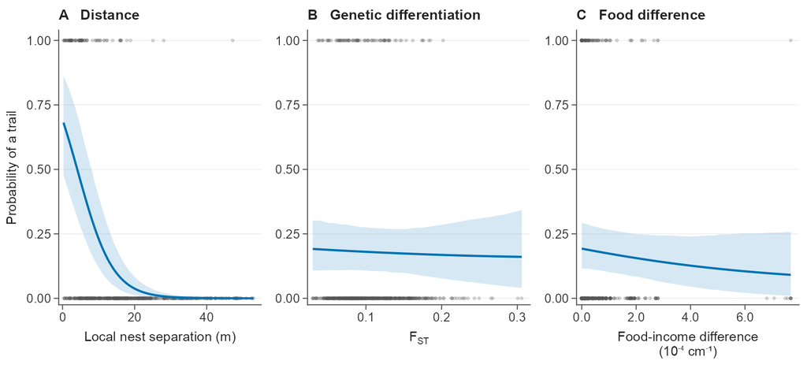

Points show all 645 observed pairs. Posterior prediction curves show mean trail probability with group-specific deviations set to zero, with posterior means and 95% credible intervals. Other predictors retain their observed values, averaged over all analysed pairs within each draw. Each curve stops at the observed predictor limits. Food difference is shown in units of 0.0001 per centimetre.  
Files: trail_presence_effects.svg · trail_presence_effects.png

```r
model_data <- model_specs$m2$data
variables <- c("distance_m", "FST_Latter", "food_difference")
presence_curve_draw_ids <- unique(round(seq(1, ndraws(model_fits$m2), length.out = min(2000, ndraws(model_fits$m2)))))
presence_curves <- setNames(lapply(variables, function(variable) {
  x <- model_data[[variable]]
  values <- seq(min(x), max(x), length.out = 100)
  # Process ten grid values at a time, retaining every pair and its other predictors.
  batches <- split(seq_along(values), ceiling(seq_along(values) / 10))
  predictions <- lapply(batches, function(ix) {
    newdata <- trail_prediction_data(model_data, trail_transformations, variable, values[ix])
    expected_draws <- posterior_epred(model_fits$m2, newdata = newdata,
      re_formula = NA, draw_ids = presence_curve_draw_ids)
    vapply(seq_along(ix), function(j) {
      rowMeans(expected_draws[, (j - 1L) * nrow(model_data) + seq_len(nrow(model_data)), drop = FALSE])
    }, numeric(nrow(expected_draws)))
  })
  bind_cols(tibble(x = values), summarize_columns(do.call(cbind, predictions)))
}), variables)
y_range <- range(model_data$response, unlist(lapply(presence_curves, function(x) c(x$lower, x$upper))))

panels <- lapply(seq_along(variables), function(j) {
  variable <- variables[j]
  plot <- ggplot() +
    geom_ribbon(data = presence_curves[[variable]], aes(x, ymin = lower, ymax = upper),
      fill = "#0072B2", alpha = .16) +
    geom_point(data = model_data, aes(x = .data[[variable]], y = response),
      colour = "#555555", alpha = .2, size = .6) +
    geom_line(data = presence_curves[[variable]], aes(x, estimate), colour = "#0072B2", linewidth = .65)
  style_trail_panel(plot, variable, j, presence = TRUE, y_range = y_range)
})
presence_figure <- arrange_panels(panels, width = 180, height = 82)
save_figure("m2_effects", presence_figure, width = 180, height = 82)
show_figure("m2_effects", paste0(
  "Points show all ", nrow(model_data), " observed pairs. Posterior prediction curves show ",
  "mean trail probability with group-specific deviations set to zero, with posterior means and 95% credible intervals. ",
  "Other predictors retain their observed values, averaged over all analysed pairs within each draw. ",
  "Each curve stops at the observed predictor limits. ",
  "Food difference is shown in units of 0.0001 per centimetre."))
```

**Interpretation.** Under the non-positive distance prior, trail probability declined at an average local rate of 1.79 percentage points per metre (95% credible interval 1.42–2.17), accounting for the other predictors and group effects. The decline was steepest among pairs up to 20 m apart (2.63 percentage points per metre), falling to 0.33 at 20–30 m and 0.04 beyond 30 m. Genetic and food associations were uncertain; their intervals included local increases and decreases in probability.

Food income and trail structure may influence each other; these associations do not establish that changing food availability would create or remove trails.

## Posterior predictive checks

```r
set.seed(seed + 300L)
model_data <- model_specs$m2$data
draw_ids <- unique(round(seq(1, ndraws(model_fits$m2), length.out = 400)))
replicated_outcomes <- posterior_predict(model_fits$m2, re_formula = NULL, draw_ids = draw_ids)
observed_outcomes <- model_data$response
predictive_checks$m2 <- posterior_predictive_summary(observed_outcomes, replicated_outcomes, "m2", list(prevalence = mean))
strata <- list(
  colony = as.character(model_data$colony),
  distance = paste("Distance quartile", dplyr::ntile(model_data$distance_m, 4))
)
show_table(posterior_group_checks(observed_outcomes, replicated_outcomes, strata),
  caption = "Posterior predictive checks of group means")
show_table(predictive_checks$m2, digits = 4)
```

Posterior predictive checks of group means

| Grouping | Groups checked | Outside 95% predictive interval |
| --- | --- | --- |
| Colony | 10 | 0 |
| Distance quartile | 4 | 0 |

| model | statistic | observed | lower_rep | median_rep | upper_rep | probability_rep_above_observed |
| --- | --- | --- | --- | --- | --- | --- |
| m2 | prevalence | 0.1302 | 0.1008 | 0.1302 | 0.1659 | 0.5025 |

Trail prevalence and all 14 colony/distance means fall within their 95% predictive ranges.

## Robustness check: FST estimator

Weir–Cockerham (WC84) estimates can be negative, preventing direct substitution as Model 1’s logit-transformed response. Here FST is a predictor: this call refits presence with WC84, retaining Latter’s predictor scaling. Preprocessing compares all three estimators.

```r
robustness_model_specs$m2_WC84 <- model_specs$m2
robustness_model_specs$m2_WC84$name <- "m2_WC84"
robustness_model_specs$m2_WC84$data <- apply_trail_scales(
  analysis_data$m2, trail_transformations, "FST_WC84")
robustness_model_specs$m2_WC84$data$response <- as.integer(robustness_model_specs$m2_WC84$data$connected)
sampling_dir <- tempfile("wood-ant-sampling-")
dir.create(sampling_dir)
robustness_fits$m2_WC84 <- brm(
  formula = robustness_model_specs$m2_WC84$formula, data = robustness_model_specs$m2_WC84$data,
  family = robustness_model_specs$m2_WC84$family, prior = robustness_model_specs$m2_WC84$prior,
  backend = "cmdstanr", chains = 4, cores = 4,
  iter = 5000L, warmup = 2000L, seed = seed, init = NULL,
  control = list(adapt_delta = .995, max_treedepth = 13, metric = "diag_e"),
  save_pars = save_pars(all = TRUE), output_dir = sampling_dir,
  refresh = 200, silent = 1
)
robustness_fits$m2_WC84 <- refine_sampling_fit(robustness_fits$m2_WC84, seed, sampling_dir)
diagnostics_m2_WC84 <- diagnose_fit(robustness_fits$m2_WC84, "m2_WC84")
show_table(diagnostics_m2_WC84)
stopifnot(all(diagnostics_m2_WC84$pass))
show_genetic_robustness(
  c(model_fits["m2"], robustness_fits["m2_WC84"]),
  c(model_specs["m2"], robustness_model_specs["m2_WC84"]), trail_transformations)
```

| model | max_rhat | min_ess_bulk | min_ess_tail | divergences | initial_divergences | initial_depth_hits | treedepth_hits | max_treedepth | min_ebfmi | pass |
| --- | --- | --- | --- | --- | --- | --- | --- | --- | --- | --- |
| m2_WC84 | 1.002 | 4499.062 | 4771.352 | 0 | 0 | 0 | 0 | 13 | 0.91 | TRUE |

| Model | AME in trail probability (percentage points per 0.01 FST) (95% credible interval) |
| --- | --- |
| Main (Latter) | -0.13 (-0.70 to 0.42) |
| WC84 | -0.15 (-0.69 to 0.38) |

Local FST slopes averaged over every analysed pair at its observed values, retaining other predictors and fitted group effects. Zero denotes no local association.

The genetic association remains uncertain with either estimator: both intervals include increases and decreases in trail probability.

# Model 3: Trail investment

This model uses the shared trail definitions and transformations above.

**Data.** Of 662 screened within-colony pairs, 85 had observed trails and 577 had no trail. One observed trail was excluded because a missing nest-size measurement prevented calculation of food difference and investment. The analysis therefore included 84 trails joining 94 nests in ten colonies. No additional trails were excluded for missing or invalid measurements.

**Trail presence and selection.** How does investment vary **among existing trails**? This conditions on trail presence. The hypothesised DAG shows selection paths, omitting other causes and any direct genetic effect on investment. $G$ is genetic differentiation, $H$ food difference, $T$ presence, $I$ investment and $U$ an unmeasured cause such as nest condition. Boxes indicate conditioning.

$$\begin{array}{ccccc}
& & \boxed{H} & \longrightarrow & I \\
& & \downarrow & & \uparrow \\
G & \longrightarrow & \boxed{T=1} & \longleftarrow & U
\end{array}$$

In this DAG, trail presence is a collider: selecting existing trails opens $G\rightarrow T\leftarrow H\rightarrow I$, which food adjustment blocks. This assumes food difference precedes formation and causes both presence and investment.

Selection also opens $G\rightarrow T\leftarrow U\rightarrow I$. Food adjustment does not block this path; nest and colony effects do not establish control. Causal interpretation would require a confounding sensitivity analysis varying how strongly $U$ affects presence and investment; this was not conducted.

For the eligible pairs with an observed positive trail:
$$\begin{aligned}
I_i\mid T_i=1 &\sim
\operatorname{Lognormal}(\eta_i^{(I)},\sigma_I),\\
\eta_i^{(I)} &=
\alpha_I+b_{D,I}z_{D,i}+b_{F,I}z_{F,i}+b_{H,I}z_{H,i}\\
&\quad+u_{a_i}^{(I)}+u_{b_i}^{(I)}+c_{0,k(i)}^{(I)}
+c_{D,k(i)}^{(I)}z_{D,i},\\
u_j^{(I)} &\sim \operatorname{Normal}(0,\tau_{u,I}),\\
\begin{bmatrix}c_{0,k}^{(I)}\\c_{D,k}^{(I)}\end{bmatrix}
&\sim
\operatorname{MVNormal}\!\left(\begin{bmatrix}0\\0\end{bmatrix},\Sigma_I\right),\\
\alpha_I &\sim \operatorname{Normal}(\log(0.003),1.2),\\
b_{D,I} &\sim \operatorname{Normal}(0,0.25),\\
b_{F,I} &\sim \operatorname{Normal}(0,0.5),\\
b_{H,I} &\sim \operatorname{Normal}(0,0.15),\\
\tau_{u,I},\tau_{0,I} &\sim \operatorname{HalfNormal}(0,0.5),\\
\tau_{D,I} &\sim \operatorname{HalfNormal}(0,0.3),\\
\sigma_I &\sim \operatorname{HalfNormal}(0,0.75),\\
\Sigma_I &= \operatorname{diag}(\tau_{0,I},\tau_{D,I})\,
\mathbf R_I\,\operatorname{diag}(\tau_{0,I},\tau_{D,I}),\\
\mathbf R_I &\sim \operatorname{LKJCorr}(2).
\end{aligned}$$

Here $\log I_i$ is normal with mean $\eta_i^{(I)}$ and residual SD $\sigma_I$, shared across observations.

## Specify the model

The main model and the tighter genetic prior assessed below are specified here.

```r
investment_data <- apply_trail_scales(analysis_data$m2b, trail_transformations)
investment_prior_settings <- list(
  intercept = c(log(.003), 1.2), slope_sd = .25, genetic_sd = .5,
  food_sd = .15, group_sd = .5, colony_slope_sd = .3,
  residual_sd = .75, correlation = 2
)
investment_data$response <- investment_data$trail_investment
stopifnot(all(is.finite(investment_data$response) & investment_data$response > 0))

# Positive investment among observed trails, with correlated colony
# intercepts and additive distance slopes; nest effects are summed.
investment_formula <- bf(response ~ 0 + Intercept + distance_z + fst_z + food_z +
  (1 + distance_z | colony) +
  (1 | mm(from_label, to_label, weights = cbind(w1, w2), scale = FALSE)))
investment_priors <- c(
  set_prior(normal_prior(0, investment_prior_settings$slope_sd), class = "b"),
  set_prior(normal_prior(investment_prior_settings$intercept[1], investment_prior_settings$intercept[2]),
    class = "b", coef = "Intercept"),
  set_prior(normal_prior(0, investment_prior_settings$group_sd), class = "sd"),
  set_prior(sprintf("lkj(%g)", investment_prior_settings$correlation), class = "cor"),
  set_prior(normal_prior(0, investment_prior_settings$colony_slope_sd), class = "sd", group = "colony", coef = "distance_z"),
  set_prior(normal_prior(0, investment_prior_settings$genetic_sd), class = "b", coef = "fst_z"),
  set_prior(normal_prior(0, investment_prior_settings$food_sd), class = "b", coef = "food_z"),
  set_prior(normal_prior(0, investment_prior_settings$residual_sd), class = "sigma")
)
model_specs$m2b <- list(
  name = "m2b", formula = investment_formula, data = investment_data, prior = investment_priors, prior_parameters = investment_prior_settings,
  family = lognormal(), response_scale = "lognormal"
)
# The robustness check changes only the genetic slope prior.
robustness_model_specs$m2b_tighter_genetic_prior <- model_specs$m2b
robustness_model_specs$m2b_tighter_genetic_prior$name <- "m2b_tighter_genetic_prior"
robustness_model_specs$m2b_tighter_genetic_prior$prior_parameters$genetic_sd <- .25
robustness_model_specs$m2b_tighter_genetic_prior$prior$prior[
  robustness_model_specs$m2b_tighter_genetic_prior$prior$coef == "fst_z"
] <- normal_prior(0, .25)
model_specs$m2b$formula
```

```
response ~ 0 + Intercept + distance_z + fst_z + food_z + (1 + distance_z | colony) + (1 | mm(from_label, to_label, weights = cbind(w1, w2), scale = FALSE))
```

## Priors and prior predictions

Investment measures allocation to one trail relative to mean nest population ([Ellis et al., 2014](https://doi.org/10.1093/beheco/aru108)). We allowed a small but uncertain baseline: the reference conditional median was centred on 0.003, with a 95% prior range of 0.00029–0.032. This is a broad biological judgement, not an empirical estimate. Half-normal nest, colony-intercept and residual SD priors allowed weak and strong trails while regularising extreme variation. Zero-centred slopes favoured smaller associations in either direction, with greater uncertainty about genetics and narrower food effects because food spanned more standardised units. LKJ(2) mildly favoured colony intercept–slope correlations near zero.

We checked that investment above one remained rare, including at the largest food predictor. This is a plausibility check, not a hard bound on the index.

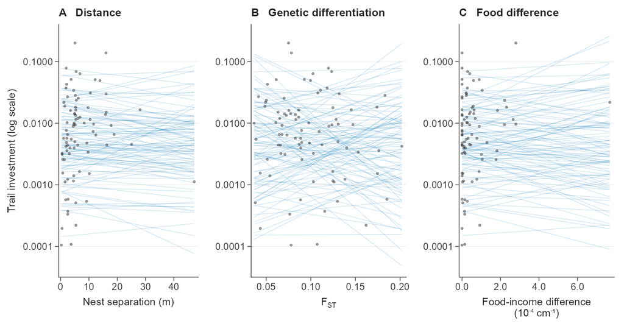

100 prior-drawn response curves per panel; points are observations for reference. Group-specific deviations are zero. Other predictors retain their observed values, averaged over the same pairs at every grid point. Curves show expected responses without observation noise; their full vertical range is shown. Observed outcomes were not used to generate the curves or revise the priors.

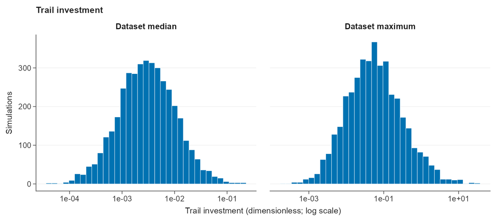

4000 simulations include all group effects and response noise, using 84 evenly spaced design rows. Each value summarises one simulated dataset.

Full prior predictions: weak and strong investment

| Investment < 0.0001 (%) | Investment < 0.001 (%) | Investment < 0.01 (%) | Investment > 1 (%) |
| --- | --- | --- | --- |
| 2.96 | 26.23 | 75.94 | 0.14 |

```r
# Expected-response curves: 100 draws, with group deviations set to zero.
set.seed(seed + 704L)
draws <- 100L
model_data <- model_specs$m2b$data
prior_settings <- model_specs$m2b$prior_parameters
intercept_draws <- rnorm(draws, prior_settings$intercept[1], prior_settings$intercept[2])
coefficient_draws <- cbind(rnorm(draws, 0, prior_settings$slope_sd), rnorm(draws, 0, prior_settings$genetic_sd),
  rnorm(draws, 0, prior_settings$food_sd))
# Arithmetic-mean investment includes residual variation.
residual_sd_draws <- abs(rnorm(draws, 0, prior_settings$residual_sd))
variables <- c("distance_m", "FST_Latter", "food_difference")
standardized_predictors <- as.matrix(model_data[, c("distance_z", "fst_z", "food_z")])
investment_prior_curves <- setNames(lapply(seq_along(variables), function(j) {
  x <- seq(min(model_data[[variables[j]]]), max(model_data[[variables[j]]]), length.out = 80L)
  predictor_scaling <- trail_transformations[match(variables[j], trail_transformations$variable), ]
  grid_z <- (x - predictor_scaling$center) / predictor_scaling$scale
  other_predictor_contribution <- intercept_draws + coefficient_draws[, -j, drop = FALSE] %*% t(standardized_predictors[, -j, drop = FALSE])
  y <- vapply(grid_z, function(value) {
    linear_predictor_draws <- other_predictor_contribution + coefficient_draws[, j] * value
    rowMeans(exp(linear_predictor_draws + residual_sd_draws^2 / 2))
  }, numeric(draws))
  long_prior_draws(x, y)
}), variables)
y_range <- range(model_data$response, unlist(lapply(investment_prior_curves, `[[`, "y")))
panels <- lapply(seq_along(variables), function(j) {
  variable <- variables[j]
  plot <- ggplot(investment_prior_curves[[j]], aes(x, y, group = draw)) +
    geom_line(colour = "#0072B2", alpha = .2, linewidth = .22) +
    geom_point(data = tibble(x = model_data[[variable]], y = model_data$response), aes(x, y),
      inherit.aes = FALSE, colour = "#222222", alpha = .4, size = .6)
  style_prior_panel(plot, variable, j, genetic = FALSE, investment = TRUE, y_range = y_range)
})
plot <- arrange_panels(panels, width = 180, height = 94)
save_figure("m2b_prior_trends", plot, width = 180, height = 94)
show_figure("m2b_prior_trends", paste0(
  "100 prior-drawn response curves per panel; points are observations for reference. ",
  "Group-specific deviations are zero. ",
  "Other predictors retain their observed values, averaged over the same pairs at every grid point. ",
  "Curves show expected responses without observation noise; their full vertical range is shown. ",
  "Observed outcomes were not used to generate the curves or revise the priors."))

# Full prior predictions include shared group effects and observation noise.
set.seed(seed + 23L)
investment_prior_simulation <- simulate_prior(model_specs$m2b, draws = 4000L)
replicated_outcomes <- investment_prior_simulation$yrep
investment_prior_summary <- tibble(`Dataset median` = apply(replicated_outcomes, 1, median),
  `Dataset maximum` = apply(replicated_outcomes, 1, max))
prior_summary_long <- investment_prior_summary |> pivot_longer(everything(), names_to = "statistic", values_to = "value") |>
  mutate(statistic = factor(statistic, levels = names(investment_prior_summary)))
plot <- ggplot(prior_summary_long, aes(value)) +
  geom_histogram(bins = 35, fill = "#0072B2", colour = "white", linewidth = .15) +
  facet_wrap(~statistic, scales = "free_x") +
  labs(x = "Trail investment (dimensionless; log scale)", y = "Simulations", title = model_label("m2b")) +
  scale_x_log10()
save_figure("m2b_prior", plot, width = 180, height = 80)
show_figure("m2b_prior", paste(4000,
  "simulations include all group effects and response noise, using", nrow(investment_prior_simulation$data),
  "evenly spaced design rows. Each value summarises one simulated dataset."))
investment_prior_tails <- tibble(
  `Investment < 0.0001 (%)` = 100 * mean(replicated_outcomes < .0001),
  `Investment < 0.001 (%)` = 100 * mean(replicated_outcomes < .001),
  `Investment < 0.01 (%)` = 100 * mean(replicated_outcomes < .01),
  `Investment > 1 (%)` = 100 * mean(replicated_outcomes > 1))
show_table(investment_prior_tails, digits = 2, caption = "Full prior predictions: weak and strong investment")
```

### Genetic-effect prior

The genetic prior $b_{F,I}\sim \operatorname{Normal}(0,0.5)$ gives a 95% prior investment-ratio range of 0.38–2.66 per FST SD, or 0.77–1.29 per 0.01 FST. It allows substantial effects in either direction without assuming that differentiation determines investment. No biological evidence used here requires the smaller effects favoured by $N(0,0.25)$.

We compare prior predictions in 40,000 simulated datasets, changing only this coefficient prior. Other coefficient, group-effect and response-noise draws are identical. The predictor design is retained; observed investment is unused.

```r
prior_width_specs <- list(`Genetic SD 0.25` = robustness_model_specs$m2b_tighter_genetic_prior,
  `Genetic SD 0.50` = model_specs$m2b)
prior_width_simulations <- map(prior_width_specs, function(model_spec) {
  # The same seed holds every other prior contribution fixed.
  set.seed(seed + 2L)
  simulate_prior(model_spec, draws = 40000L)
})
prior_width_tails <- genetic_prior_tail_summary(prior_width_simulations)
show_table(prior_width_tails, digits = 4, caption = "Prior tail probabilities (%): genetic prior alone")
```

Prior tail probabilities (%): genetic prior alone

| prior | design | Investment > 1 (%) | Investment > 10 (%) |
| --- | --- | --- | --- |
| Genetic SD 0.25 | All trail designs | 0.1171 | 0.0053 |
| Genetic SD 0.25 | Smallest FST | 0.1250 | 0.0000 |
| Genetic SD 0.25 | Largest FST | 0.1600 | 0.0075 |
| Genetic SD 0.25 | Largest food predictor | 0.2750 | 0.0150 |
| Genetic SD 0.50 | All trail designs | 0.1436 | 0.0063 |
| Genetic SD 0.50 | Smallest FST | 0.1850 | 0.0050 |
| Genetic SD 0.50 | Largest FST | 0.4725 | 0.0200 |
| Genetic SD 0.50 | Largest food predictor | 0.3275 | 0.0125 |

Both genetic priors allow weak investment while keeping values above one rare. Across the full FST range, the wider prior allows a broad 95% investment-ratio range (about 0.014–72). We retained $N(0,0.5)$ to allow substantial associations in either direction, independently of whether its posterior interval excludes zero; $N(0,0.25)$ remains a robustness check.

## Fit and check the model

`brm()` fits the model; the next chunk checks sampling.

```r
sampling_dir <- tempfile("wood-ant-sampling-")
dir.create(sampling_dir)
model_fits$m2b <- brm(
  formula = model_specs$m2b$formula, data = model_specs$m2b$data,
  family = model_specs$m2b$family, prior = model_specs$m2b$prior,
  backend = "cmdstanr", chains = 4, cores = 4,
  iter = 3500L, warmup = 1500L, seed = 20261021L, init = NULL,
  control = list(adapt_delta = .995, max_treedepth = 13, metric = "diag_e"),
  save_pars = save_pars(all = TRUE), output_dir = sampling_dir,
  refresh = 200, silent = 1
)
model_fits$m2b <- refine_sampling_fit(model_fits$m2b, 20261021L, sampling_dir)
```

```r
investment_diagnostics <- diagnose_fit(model_fits$m2b, "m2b")
show_table(investment_diagnostics)
stopifnot(all(investment_diagnostics$pass))
```

| model | max_rhat | min_ess_bulk | min_ess_tail | divergences | initial_divergences | initial_depth_hits | treedepth_hits | max_treedepth | min_ebfmi | pass |
| --- | --- | --- | --- | --- | --- | --- | --- | --- | --- | --- |
| m2b | 1.008 | 954.557 | 2095.413 | 0 | 0 | 0 | 0 | 13 | 0.461 | TRUE |

## Results

We reported mean predicted investment on its original scale, accounting for residual variation. The table reports average marginal effects on arithmetic-mean investment among existing trails. Predictor units are the same as Model 2. Investment is dimensionless; zero indicates no local association.

```r
model_data <- model_specs$m2b$data
investment_result_draw_ids <- seq_len(ndraws(model_fits$m2b))
ame_settings <- tibble(
  variable = c("distance_m", "FST_Latter", "food_difference"),
  unit = c(1, .01, .0001), derivative_step = c(.01, 1e-5, 1e-7),
  label = c("Distance (per m)", "FST (per 0.01)", "Food-income difference (per 0.0001/cm)")
)
# Local arithmetic-mean slopes retain all observed trails and fitted group effects.
investment_marginal_effect_draws <- lapply(seq_len(nrow(ame_settings)), function(j) {
  local_slopes <- trail_local_slopes(model_fits$m2b, model_specs$m2b, trail_transformations,
    variable = ame_settings$variable[j], derivative_step = ame_settings$derivative_step[j], draw_ids = investment_result_draw_ids)
  # Investment per stated predictor unit, averaged within each posterior draw.
  ame_settings$unit[j] * rowMeans(local_slopes)
})
investment_marginal_effect_draws <- do.call(cbind, investment_marginal_effect_draws)
colnames(investment_marginal_effect_draws) <- ame_settings$variable
investment_effects <- list(estimates = bind_cols(
  tibble(Predictor = ame_settings$label, Pairs = nrow(model_data)), summarize_columns(investment_marginal_effect_draws)),
  draws = investment_marginal_effect_draws)
show_trail_results(investment_effects, presence = FALSE)
```

Average marginal effects at the observed predictor values

| Predictor | Pairs | AME in mean investment (95% credible interval) |
| --- | --- | --- |
| Distance (per m) | 84 | -0.00013 (-0.00099 to 0.00056) |
| FST (per 0.01) | 84 | -0.00156 (-0.00354 to -0.00002) |
| Food-income difference (per 0.0001/cm) | 84 | 0.00267 (-0.00131 to 0.00735) |

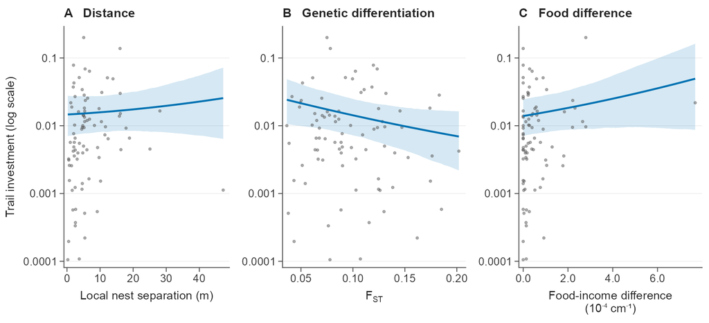

Points show all 84 observed pairs. Posterior prediction curves show arithmetic-mean investment with group-specific deviations set to zero, with posterior means and 95% credible intervals. Other predictors retain their observed values, averaged over all analysed pairs within each draw. Each curve stops at the observed predictor limits. Investment uses a logarithmic vertical axis. Food difference is shown in units of 0.0001 per centimetre.  
Files: trail_investment_effects.svg · trail_investment_effects.png

```r
model_data <- model_specs$m2b$data
variables <- c("distance_m", "FST_Latter", "food_difference")
investment_curve_draw_ids <- unique(round(seq(1, ndraws(model_fits$m2b), length.out = min(2000, ndraws(model_fits$m2b)))))
investment_curves <- setNames(lapply(variables, function(variable) {
  x <- model_data[[variable]]
  values <- seq(min(x), max(x), length.out = 100)
  # Process ten grid values at a time, retaining every pair and its other predictors.
  batches <- split(seq_along(values), ceiling(seq_along(values) / 10))
  predictions <- lapply(batches, function(ix) {
    newdata <- trail_prediction_data(model_data, trail_transformations, variable, values[ix])
    expected_draws <- posterior_epred(model_fits$m2b, newdata = newdata,
      re_formula = NA, draw_ids = investment_curve_draw_ids)
    vapply(seq_along(ix), function(j) {
      rowMeans(expected_draws[, (j - 1L) * nrow(model_data) + seq_len(nrow(model_data)), drop = FALSE])
    }, numeric(nrow(expected_draws)))
  })
  bind_cols(tibble(x = values), summarize_columns(do.call(cbind, predictions)))
}), variables)
y_range <- range(model_data$response, unlist(lapply(investment_curves, function(x) c(x$lower, x$upper))))
stopifnot(all(is.finite(y_range)), all(y_range > 0))
panels <- lapply(seq_along(variables), function(j) {
  variable <- variables[j]
  plot <- ggplot() +
    geom_ribbon(data = investment_curves[[variable]], aes(x, ymin = lower, ymax = upper),
      fill = "#0072B2", alpha = .16) +
    geom_point(data = model_data, aes(x = .data[[variable]], y = response),
      colour = "#555555", alpha = .45, size = .6) +
    geom_line(data = investment_curves[[variable]], aes(x, estimate), colour = "#0072B2", linewidth = .65)
  style_trail_panel(plot, variable, j, presence = FALSE, y_range = y_range)
})
investment_figure <- arrange_panels(panels, width = 180, height = 82)
save_figure("m2b_effects", investment_figure, width = 180, height = 82)
show_figure("m2b_effects", paste0(
  "Points show all ", nrow(model_data), " observed pairs. Posterior prediction curves show ",
  "arithmetic-mean investment with group-specific deviations set to zero, with posterior means and 95% credible intervals. ",
  "Other predictors retain their observed values, averaged over all analysed pairs within each draw. ",
  "Each curve stops at the observed predictor limits. ",
  "Investment uses a logarithmic vertical axis. ",
  "Food difference is shown in units of 0.0001 per centimetre."))
```

**Interpretation.** Among existing trails, the average local genetic slope was −0.00156 investment units per 0.01 FST (95% credible interval −0.00354 to −0.00002). This suggests lower investment at greater genetic differentiation, although the magnitude remains uncertain. Both WC84 and tighter-prior intervals included no association. Distance and food associations were uncertain.

### Additional food plot on log scale

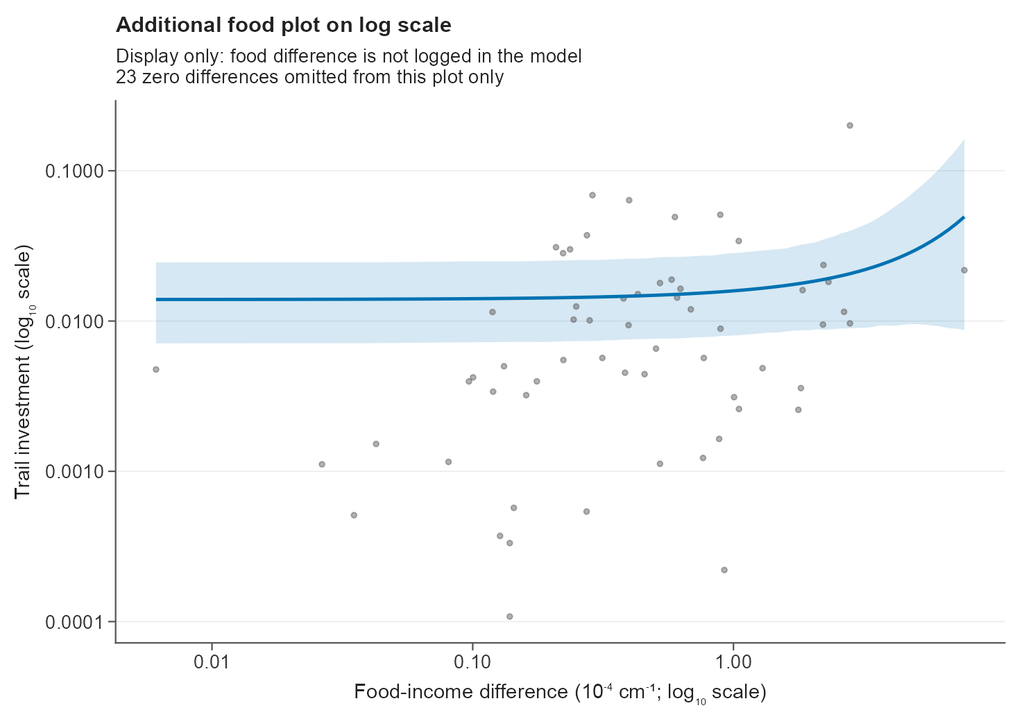

Posterior mean and 95% credible interval over the observed positive food-difference range. Group-specific deviations are zero; other predictors are averaged over all 84 analysed pairs. Points show the 61 trails with positive food differences.

```r
# Display the same relationship over positive food differences on a log axis.
positive_food <- filter(model_data, food_difference > 0)
food_grid_log <- exp(seq(log(min(positive_food$food_difference)),
  log(max(positive_food$food_difference)), length.out = 100))
# Keep all analysed pairs when averaging predictions; only the displayed points exclude zeros.
food_newdata_log <- trail_prediction_data(model_data, trail_transformations, "food_difference", food_grid_log)
food_prediction_draws_log <- posterior_epred(model_fits$m2b, newdata = food_newdata_log,
  re_formula = NA, draw_ids = investment_curve_draw_ids)
food_means_log <- vapply(seq_along(food_grid_log), function(j) {
  rowMeans(food_prediction_draws_log[, (j - 1L) * nrow(model_data) + seq_len(nrow(model_data)), drop = FALSE])
}, numeric(length(investment_curve_draw_ids)))
food_curve_log <- bind_cols(tibble(x = food_grid_log), summarize_columns(food_means_log))
food_posterior_plot_log <- ggplot(food_curve_log, aes(x, estimate)) +
  geom_ribbon(aes(ymin = lower, ymax = upper), fill = "#0072B2", alpha = .16) +
  geom_point(data = positive_food, aes(x = food_difference, y = response),
    inherit.aes = FALSE, colour = "#555555", alpha = .45, size = .8) +
  geom_line(colour = "#0072B2", linewidth = .65) +
  scale_x_log10(breaks = c(1e-6, 1e-5, 1e-4),
    labels = function(x) scales::number(x * 1e4, accuracy = .01)) +
  scale_y_log10(limits = y_range, labels = scales::label_number()) +
  labs(title = "Additional food plot on log scale",
    subtitle = paste("Display only: food difference is not logged in the model",
      paste(sum(model_data$food_difference == 0), "zero differences omitted from this plot only"), sep = "\n"),
    x = "Food-income difference (10⁻⁴ cm⁻¹; log₁₀ scale)",
    y = "Trail investment (log₁₀ scale)")
save_figure("m2b_posterior_food_log_axis", food_posterior_plot_log, width = 150, height = 105)
show_figure("m2b_posterior_food_log_axis", paste0(
  "Posterior mean and 95% credible interval over the observed positive food-difference range. ",
  "Group-specific deviations are zero; other predictors are averaged over all ", nrow(model_data), " analysed pairs. ",
  "Points show the ", nrow(positive_food), " trails with positive food differences."))
```

The horizontal axis is logarithmic for display only; food difference is not logged in the model. The 23 trails with zero food difference cannot appear on this axis but remain in the analysis and the original plot above. We have not used a log-plus-one transformation in the model because the arbitrary added constant can change the fitted relationship and inference ([Ekwaru and Veugelers, 2018](https://doi.org/10.1080/19466315.2017.1369900)).

## Posterior predictive checks

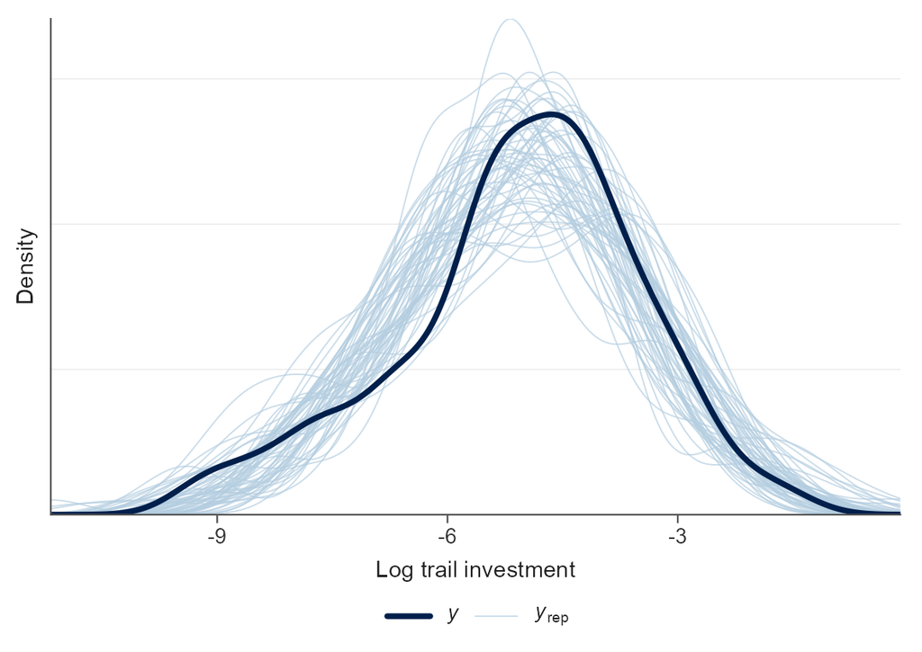

Observed log investment (dark line) and posterior replications (light lines).

Posterior predictive checks of group means

| Grouping | Groups checked | Outside 95% predictive interval |
| --- | --- | --- |
| Colony | 10 | 0 |
| Distance quartile | 4 | 0 |

| model | statistic | observed | lower_rep | median_rep | upper_rep | probability_rep_above_observed |
| --- | --- | --- | --- | --- | --- | --- |
| m2b | minimum | 0.0001 | 0.0000 | 0.0001 | 0.0004 | 0.5750 |
| m2b | median | 0.0075 | 0.0042 | 0.0066 | 0.0100 | 0.2725 |
| m2b | maximum | 0.2002 | 0.0846 | 0.2068 | 1.0417 | 0.5300 |
| m2b | sd | 0.0293 | 0.0170 | 0.0336 | 0.1335 | 0.6175 |

```r
set.seed(seed + 400L)
model_data <- model_specs$m2b$data
draw_ids <- unique(round(seq(1, ndraws(model_fits$m2b), length.out = 400)))
replicated_outcomes <- posterior_predict(model_fits$m2b, re_formula = NULL, draw_ids = draw_ids)
observed_outcomes <- model_data$response
predictive_checks$m2b <- posterior_predictive_summary(observed_outcomes, replicated_outcomes, "m2b",
  list(minimum = min, median = median, maximum = max, sd = sd))
plot <- bayesplot::ppc_dens_overlay(log(observed_outcomes), log(replicated_outcomes[1:60, , drop = FALSE])) +
  labs(x = "Log trail investment", y = "Density")
save_figure("m2b_ppc", plot, width = 120, height = 85)
show_figure("m2b_ppc", "Observed log investment (dark line) and posterior replications (light lines).")
strata <- list(
  colony = as.character(model_data$colony),
  distance = paste("Distance quartile", dplyr::ntile(model_data$distance_m, 4))
)
show_table(posterior_group_checks(observed_outcomes, replicated_outcomes, strata),
  caption = "Posterior predictive checks of group means")
show_table(predictive_checks$m2b, digits = 4)
```

All four overall summaries and 14 colony/distance means fall within their 95% predictive ranges.

## Robustness checks: FST estimator and genetic prior

We replace Latter FST with WC84, retaining the main-model predictor scaling, and separately tighten only the genetic-effect prior to Normal(0, 0.25).

```r
robustness_model_specs$m2b_WC84 <- model_specs$m2b
robustness_model_specs$m2b_WC84$name <- "m2b_WC84"
robustness_model_specs$m2b_WC84$data <- apply_trail_scales(
  analysis_data$m2b, trail_transformations, "FST_WC84")
robustness_model_specs$m2b_WC84$data$response <- robustness_model_specs$m2b_WC84$data$trail_investment
for (model_name in c("m2b_WC84", "m2b_tighter_genetic_prior")) {
  sampling_dir <- tempfile("wood-ant-sampling-")
  dir.create(sampling_dir)
  robustness_fits[[model_name]] <- brm(
    formula = robustness_model_specs[[model_name]]$formula, data = robustness_model_specs[[model_name]]$data,
    family = robustness_model_specs[[model_name]]$family, prior = robustness_model_specs[[model_name]]$prior,
    backend = "cmdstanr", chains = 4, cores = 4,
    iter = 3500L, warmup = 1500L, seed = seed, init = NULL,
    control = list(adapt_delta = .995, max_treedepth = 13, metric = "diag_e"),
    save_pars = save_pars(all = TRUE), output_dir = sampling_dir,
    refresh = 200, silent = 1
  )
  robustness_fits[[model_name]] <- refine_sampling_fit(robustness_fits[[model_name]], seed, sampling_dir)
  diagnostics_robustness <- diagnose_fit(robustness_fits[[model_name]], model_name)
  show_table(diagnostics_robustness)
  stopifnot(all(diagnostics_robustness$pass))
}
investment_robustness <- c("m2b_WC84", "m2b_tighter_genetic_prior")
show_genetic_robustness(
  c(model_fits["m2b"], robustness_fits[investment_robustness]),
  c(model_specs["m2b"], robustness_model_specs[investment_robustness]), trail_transformations)
```

| model | max_rhat | min_ess_bulk | min_ess_tail | divergences | initial_divergences | initial_depth_hits | treedepth_hits | max_treedepth | min_ebfmi | pass |
| --- | --- | --- | --- | --- | --- | --- | --- | --- | --- | --- |
| m2b_WC84 | 1.002 | 1033.105 | 1209.775 | 0 | 0 | 0 | 0 | 13 | 0.465 | TRUE |

| model | max_rhat | min_ess_bulk | min_ess_tail | divergences | initial_divergences | initial_depth_hits | treedepth_hits | max_treedepth | min_ebfmi | pass |
| --- | --- | --- | --- | --- | --- | --- | --- | --- | --- | --- |
| m2b_tighter_genetic_prior | 1.004 | 860.775 | 1214.023 | 0 | 0 | 0 | 0 | 13 | 0.497 | TRUE |

| Model | AME in mean investment per 0.01 FST (95% credible interval) |
| --- | --- |
| Main (Latter) | -0.00156 (-0.00354 to -0.00002) |
| WC84 | -0.00141 (-0.00337 to 0.00010) |
| Tighter genetic prior | -0.00122 (-0.00290 to 0.00013) |

Local FST slopes averaged over every analysed pair at its observed values, retaining other predictors and fitted group effects. Zero denotes no local association.

The genetic association was negative on average under all three specifications. The main interval ended just below zero, while both WC84 and tighter-prior intervals included zero; the magnitude remains uncertain.